# Application Project Umsatzprognose Bäckerei

### Direkte Schätzung des Testfehlers

Nun wird der Fehler der Testdaten für das beste Modell jeder Modellgröße berechnet. Zuerst wird eine Modellmatrix aus den Testdaten erstellt. Die Funktion `model.matrix` wird in vielen Regressionspaketen zum Erstellen einer X-Matrix aus Daten verwendet.

```r
test_m <- model.matrix(Umsatz ~ ., data = df_lm_test_WG1)
```

```r
# Erstellen eines leeren Vektors, um diesen nachfolgend mit den Fehlerwerten zu füllen
validation_errors <- vector("double", length = 36)

for(i in 1:36) {
  coef_x <- coef(best_subset_WG1, id = i)                     # extract coefficients for model size i
  pred_x <- test_m[ , names(coef_x)] %*% coef_x           # predict salary using matrix algebra
  validation_errors[i] <- mean((df_lm_test_WG1$Umsatz - pred_x)^2)  # compute test error btwn actual & predicted salary
}

as.matrix(validation_errors)
```

```
##            [,1]
##  [1,] 1734.0414
##  [2,] 1557.4956
##  [3,] 1385.7611
##  [4,] 1197.9912
##  [5,] 1145.8014
##  [6,] 1188.4607
##  [7,] 1105.6298
##  [8,] 1066.3385
##  [9,] 1100.1184
## [10,] 1047.0326
## [11,] 1030.2300
## [12,] 1012.2062
## [13,]  971.9783
## [14,]  970.7560
```

[output cut: 22 more lines]

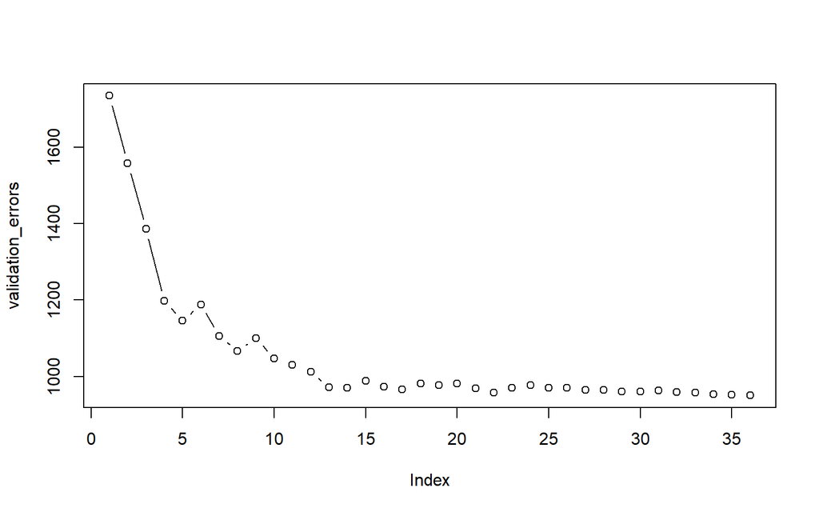

```r
# Plotten der validation errors
plot(validation_errors, type = "b")
```

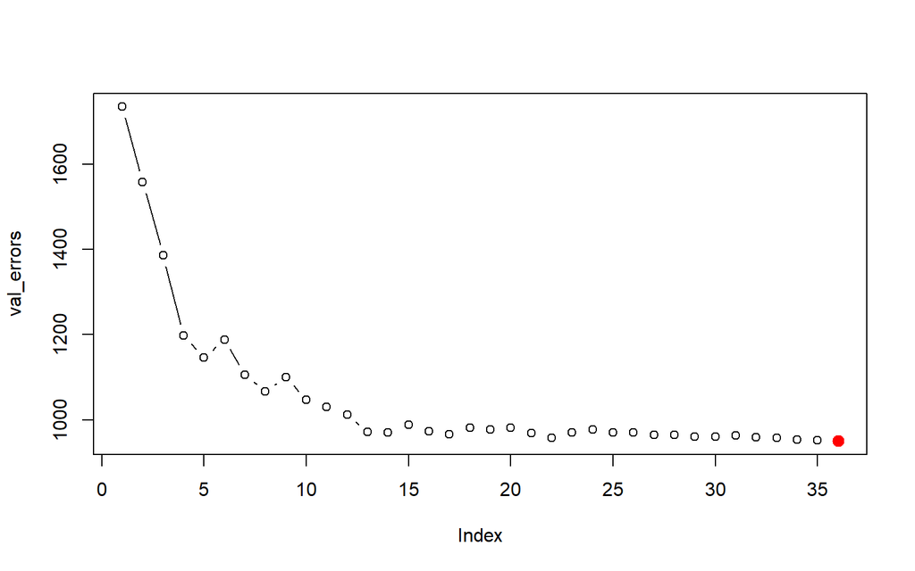

```r
#############################
# Alternative: http://www.science.smith.edu/~jcrouser/SDS293/labs/lab9-r.html
val_errors = rep(NA,36)

# Iterationen über jede Größe i
for(i in 1:36){

    # Extrahieren des Vektors der Prädiktoren im Best-Fit-Modell für i-Prädiktoren
    coefi = coef(best_subset_WG1, id = i)

    # Vorhersagen unter Verwendung der Matrixmultiplikation der Testmatrix und des Koeffizientenvektors erstellen
    pred = test_m[,names(coefi)]%*%coefi

    # Berechnung des MSE
    val_errors[i] = mean((df_lm_test_WG1$Umsatz-pred)^2)
}

# Auffinden des Modells mit dem kleinsten Fehler
min = which.min(val_errors)

# Plotten des Fehlers für jede Modellgröße
plot(val_errors, type = 'b')
points(min, val_errors[min][1], col = "red", cex = 2, pch = 20)
```

Es ist erkennbar, dass ein 36-Variablen-Modell, das durch den besten Teilmengenansatz erzeugt wird, den niedrigsten Test-MSE erzeugt. Auch ein 22- sowie 28-Variablen-Modell scheinen vergleichweichsweise gut zu performen.

Wir können jetzt die beste Teilmengenauswahl für den gesamten Datensatz durchführen, um zum einen das 28-Variblen-Modell zu erhalten. Dieses Modell wird mit dem 36-Variablen-Modell verglichen.

**Teilmengenauswahl für das 28-Variablen-Modell**

```r
final_best28 <- regsubsets(Umsatz ~ ., data = df_lm_train_WG1, nvmax = 36)
coef(final_best28, 28)
```

```
##            (Intercept)            KielerWoche  Wochentag_cDonnerstag
##             118.934071              19.646713              17.369164
##     Wochentag_cFreitag      Wochentag_cMontag     Wochentag_cSamstag
##              11.769074              16.473875              25.359793
##     Wochentag_cSonntag        Monat_cDezember         Monat_cFebruar
##             -41.827731              12.156381             -17.535670
##          Monat_cJanuar             Monat_cMai            Monat_cMärz
##             -20.169486              -8.356671              -8.762999
##        Monat_cNovember         Monat_cOktober       Monat_cSeptember
##              14.846819              32.878099              16.958510
##         SommerferienSH        SommerferienNRW        SommerferienNDS
##              15.399517              13.436034              12.042815
##         SommerferienHE               Feiertag                 Ostern
##               8.175215             107.216742            -292.427112
##     ChristiHimmelfahrt              Pfingsten                    TDE
##            -186.328954            -154.018667            -178.648619
##             Ostern_ext ChristiHimmelfahrt_ext          Pfingsten_ext
##             157.623977              22.780649              33.769368
##       JahreszeitHerbst       JahreszeitSommer
##             -31.098479             -15.010203
```

Die 28 Variablen sind die folgenden:

- KielerWoche
- Wochentag_cDonnerstag
- Wochentag_cFreitag
- Wochentag_cMontag
- Wochentag_cSamstag
- Wochentag_cSonntag
- Monat_cDezember
- Monat_cFebruar
- Monat_cJanuar
- Monat_cMai
- Monat_cMärz
- Monat_cNovember
- Monat_cOktober
- Monat_cSeptember
- SommerferienSH
- SommerferienNRW
- SommerferienNDS
- SommerferienHE
- Feiertag
- Ostern
- ChristiHimmelfahrt
- Pfingsten
- TDE
- Ostern_ext
- ChristiHimmelfahrt_ext
- Pfingsten_ext
- JahreszeitHerbst
- JahreszeitSommer

Insbesondere für das 28-Variablen-Modell müssen die Variablen Wochentag_c, Monat und Jahreszeit nun noch dummyfiziert werden (bei Einbeziehung aller Variablen erfolgt die Dummyfizierung automatisch im Rahmen der Regressionsanalyse): Für jeden Wochentag wird eine Variable mit Ausprägung 0/1 gebildet und danach die alte Variable Wochentag_c entfernt. Analog wird bei den beiden anderen Variablen vorgegangen.

```r
# Dummyfizierung der Variablen im Trainigsdatensatz:
df_lm_train_WG1_28 <- df_lm_train_WG1 %>%
  mutate(Montag=as.integer(df_lm_train_WG1$Wochentag_c=="Montag")) %>%
  mutate(Dienstag=as.integer(df_lm_train_WG1$Wochentag_c=="Dienstag")) %>%
  mutate(Mittwoch=as.integer(df_lm_train_WG1$Wochentag_c=="Mittwoch")) %>%
  mutate(Donnerstag=as.integer(df_lm_train_WG1$Wochentag_c=="Donnerstag")) %>%
  mutate(Freitag=as.integer(df_lm_train_WG1$Wochentag_c=="Freitag")) %>%
  mutate(Samstag=as.integer(df_lm_train_WG1$Wochentag_c=="Samstag")) %>%
  mutate(Sonntag=as.integer(df_lm_train_WG1$Wochentag_c=="Sonntag")) %>%
  mutate(Januar=as.integer(df_lm_train_WG1$Monat_c=="Januar")) %>%
  mutate(Februar=as.integer(df_lm_train_WG1$Monat_c=="Februar")) %>%
  mutate(Maerz=as.integer(df_lm_train_WG1$Monat_c=="März")) %>%
  mutate(April=as.integer(df_lm_train_WG1$Monat_c=="April")) %>%
  mutate(Mai=as.integer(df_lm_train_WG1$Monat_c=="Mai")) %>%
  mutate(Juni=as.integer(df_lm_train_WG1$Monat_c=="Juni")) %>%
  mutate(Juli=as.integer(df_lm_train_WG1$Monat_c=="Juli")) %>%
  mutate(August=as.integer(df_lm_train_WG1$Monat_c=="August")) %>%
  mutate(September=as.integer(df_lm_train_WG1$Monat_c=="September")) %>%
  mutate(Oktober=as.integer(df_lm_train_WG1$Monat_c=="Oktober")) %>%
  mutate(November=as.integer(df_lm_train_WG1$Monat_c=="November")) %>%
  mutate(Dezember=as.integer(df_lm_train_WG1$Monat_c=="Dezember")) %>%
  mutate(Fruehling=as.integer(df_lm_train_WG1$Jahreszeit=="Fruehling")) %>%
  mutate(Sommer=as.integer(df_lm_train_WG1$Jahreszeit=="Sommer")) %>%
  mutate(Herbst=as.integer(df_lm_train_WG1$Jahreszeit=="Herbst")) %>%
  mutate(Winter=as.integer(df_lm_train_WG1$Jahreszeit=="Winter")) %>%
  dplyr::select(-Wochentag_c, -Monat_c, Jahreszeit)

df_lm_test_WG1_28 <- df_lm_test_WG1 %>%
  mutate(Montag=as.integer(df_lm_test_WG1$Wochentag_c=="Montag")) %>%
  mutate(Dienstag=as.integer(df_lm_test_WG1$Wochentag_c=="Dienstag")) %>%
  mutate(Mittwoch=as.integer(df_lm_test_WG1$Wochentag_c=="Mittwoch")) %>%
  mutate(Donnerstag=as.integer(df_lm_test_WG1$Wochentag_c=="Donnerstag")) %>%
  mutate(Freitag=as.integer(df_lm_test_WG1$Wochentag_c=="Freitag")) %>%
  mutate(Samstag=as.integer(df_lm_test_WG1$Wochentag_c=="Samstag")) %>%
  mutate(Sonntag=as.integer(df_lm_test_WG1$Wochentag_c=="Sonntag")) %>%
  mutate(Januar=as.integer(df_lm_test_WG1$Monat_c=="Januar")) %>%
  mutate(Februar=as.integer(df_lm_test_WG1$Monat_c=="Februar")) %>%
  mutate(Maerz=as.integer(df_lm_test_WG1$Monat_c=="März")) %>%
  mutate(April=as.integer(df_lm_test_WG1$Monat_c=="April")) %>%
  mutate(Mai=as.integer(df_lm_test_WG1$Monat_c=="Mai")) %>%
  mutate(Juni=as.integer(df_lm_test_WG1$Monat_c=="Juni")) %>%
  mutate(Juli=as.integer(df_lm_test_WG1$Monat_c=="Juli")) %>%
  mutate(August=as.integer(df_lm_test_WG1$Monat_c=="August")) %>%
  mutate(September=as.integer(df_lm_test_WG1$Monat_c=="September")) %>%
  mutate(Oktober=as.integer(df_lm_test_WG1$Monat_c=="Oktober")) %>%
  mutate(November=as.integer(df_lm_test_WG1$Monat_c=="November")) %>%
  mutate(Dezember=as.integer(df_lm_test_WG1$Monat_c=="Dezember")) %>%
  mutate(Fruehling=as.integer(df_lm_test_WG1$Jahreszeit=="Fruehling")) %>%
  mutate(Sommer=as.integer(df_lm_test_WG1$Jahreszeit=="Sommer")) %>%
  mutate(Herbst=as.integer(df_lm_test_WG1$Jahreszeit=="Herbst")) %>%
  mutate(Winter=as.integer(df_lm_test_WG1$Jahreszeit=="Winter")) %>%
  dplyr::select(-Wochentag_c, -Monat_c, -Jahreszeit)
```

Für das 28-Variablenmodell wird nun ein Regressionsmodell erstellt:

```r
lm_WG1_28_train <- lm(Umsatz ~ KielerWoche + Donnerstag + Freitag + Montag + Samstag + Sonntag + Dezember + Februar + Januar + Mai + Maerz + November + Oktober + September + SommerferienSH + SommerferienNRW + SommerferienNDS + SommerferienHE + Feiertag + Ostern + ChristiHimmelfahrt + Pfingsten + TDE + Ostern_ext + ChristiHimmelfahrt_ext + Pfingsten_ext + Herbst + Sommer, data = df_lm_train_WG1_28)

library(broom)
glance(lm_WG1_28_train)
```

```
## # A tibble: 1 x 11
##   r.squared adj.r.squared sigma statistic   p.value    df logLik    AIC
##       <dbl>         <dbl> <dbl>     <dbl>     <dbl> <int>  <dbl>  <dbl>
## 1     0.547         0.538  26.9      60.0 3.51e-216    29 -6674. 13408.
## # ... with 3 more variables: BIC <dbl>, deviance <dbl>, df.residual <int>
```

Dann wird (die Modellgüte) anhand der *Test*-Stichprobe getestet:

```r
lm_WG1_28_predict <- predict(lm_WG1_28_train, newdata = df_lm_test_WG1_28)
```

Als Ergebnis wird ein Vektor erzeugt, der für jede Beobachtung des Test-Samples den geschätzten (vorhergesagten) Umsatzwert speichert. Die Gütewerte lassen sich mit `caret::postResample` ausgeben:

```r
caret::postResample(pred = lm_WG1_28_predict, obs = df_lm_test_WG1_28$Umsatz)
```

```
##       RMSE   Rsquared        MAE
## 31.0716942  0.5700155 23.3668499
```

```r
# Hinzufügen der Ergebnisse
df_lm_test_WG1_28 <- df_lm_test_WG1_28 %>%
  mutate(predicted = lm_WG1_28_predict)

# ergänze Prognose_zuhoch (TRUE / FALSE), Abweichung (Schätzer - Umsatz), absolute Abweichung (Abweichung_abs), relative Abweichung (Abweichung_rel), quadratische Abweichung (Abweichung_quad)
df_lm_test_WG1_28 <- df_lm_test_WG1_28 %>%
  mutate(Prognose_zuhoch = (predicted >= Umsatz)) %>%
  mutate(Abweichung = predicted - Umsatz) %>%
  mutate(Abweichung_abs = abs(predicted - Umsatz)) %>%
  mutate(Abweichung_rel = (predicted - Umsatz) / Umsatz) %>%
  mutate(Abweichung_quad = Abweichung^2)

# Ergänze die benötigten Hilfsgrößen
df_lm_test_WG1_28 <-df_lm_test_WG1_28 %>%
  mutate(Abweichung_rel_abs = abs(Abweichung_rel), Abweichung_rel_abs_mult_umsatz = Abweichung_rel_abs * Umsatz)

# Prognosegüte: mittlere Abweichung, mittlere absolute / relative Abweichung, mittlere quadratische Abweichung
temp <- df_lm_test_WG1_28 %>%
  group_by() %>%
  summarise(Anzahl=n(), Umsatz_ges = round(sum(Umsatz)), Umsatz_mittel = round(sum(Umsatz)/n()), MAE = round(mean(Abweichung_abs)), MPE = round(mean(Abweichung_rel)*100), MAPE = round(mean(Abweichung_rel_abs)*100), WAPE = round(sum(Abweichung_rel_abs_mult_umsatz)/sum(Umsatz)*100), MSE = round(mean(Abweichung_quad)), RMSE = round(sqrt(mean(Abweichung_quad))))

# füge das Modell hinzu
temp <- temp %>% mutate(Modell = "best28_WG1")

# füge die Kennzahlen nun an die Vergleichstabelle
lm_vgl_kennz <- temp
lm_vgl_kennz
```

```
## # A tibble: 1 x 10
##   Anzahl Umsatz_ges Umsatz_mittel   MAE   MPE  MAPE  WAPE   MSE  RMSE
##    <int>      <dbl>         <dbl> <dbl> <dbl> <dbl> <dbl> <dbl> <dbl>
## 1    346      45738           132    23    -4    18    18   965    31
## # ... with 1 more variable: Modell <chr>
```

**36-Variablen-Modell**

Dieses Modell wird nun verglichen mit dem 36-Variablen-Modell:

```r
lm_WG1_36_train <- lm(Umsatz ~ ., data = df_lm_train_WG1)
glance(lm_WG1_36_train)
```

```
## # A tibble: 1 x 11
##   r.squared adj.r.squared sigma statistic   p.value    df logLik    AIC
##       <dbl>         <dbl> <dbl>     <dbl>     <dbl> <int>  <dbl>  <dbl>
## 1     0.549         0.537  26.9      45.4 1.88e-209    38 -6672. 13421.
## # ... with 3 more variables: BIC <dbl>, deviance <dbl>, df.residual <int>
```

```r
lm_WG1_36_predict <- predict(lm_WG1_36_train, newdata = df_lm_test_WG1)
```

Als Ergebnis wird ein Vektor erzeugt, der für jede Beobachtung des Test-Samples den geschätzten (vorhergesagten) Umsatzwert speichert. Die Gütewerte lassen sich mit `caret::postResample` ausgeben:

```r
caret::postResample(pred = lm_WG1_36_predict, obs = df_lm_test_WG1$Umsatz)
```

```
##       RMSE   Rsquared        MAE
## 30.8056218  0.5781609 23.1506032
```

```r
df_lm_test_WG1_36 <- df_lm_test_WG1

# Hinzufügen der Ergebnisse
df_lm_test_WG1_36 <- df_lm_test_WG1_36 %>%
  mutate(predicted = lm_WG1_36_predict)

# ergänze Prognose_zuhoch (TRUE / FALSE), Abweichung (Schätzer - Umsatz), absolute Abweichung (Abweichung_abs), relative Abweichung (Abweichung_rel), quadratische Abweichung (Abweichung_quad)
df_lm_test_WG1_36 <- df_lm_test_WG1_36 %>%
  mutate(Prognose_zuhoch = (predicted >= Umsatz)) %>%
  mutate(Abweichung = predicted - Umsatz) %>%
  mutate(Abweichung_abs = abs(predicted - Umsatz)) %>%
  mutate(Abweichung_rel = (predicted - Umsatz) / Umsatz) %>%
  mutate(Abweichung_quad = Abweichung^2)

# Ergänze die benötigten Hilfsgrößen
df_lm_test_WG1_36 <-df_lm_test_WG1_36 %>%
  mutate(Abweichung_rel_abs = abs(Abweichung_rel), Abweichung_rel_abs_mult_umsatz = Abweichung_rel_abs * Umsatz)

# Prognosegüte: mittlere Abweichung, mittlere absolute / relative Abweichung, mittlere quadratische Abweichung
temp <- df_lm_test_WG1_36 %>%
  group_by() %>%
  summarise(Anzahl=n(), Umsatz_ges = round(sum(Umsatz)), Umsatz_mittel = round(sum(Umsatz)/n()), MAE = round(mean(Abweichung_abs)), MPE = round(mean(Abweichung_rel)*100), MAPE = round(mean(Abweichung_rel_abs)*100), WAPE = round(sum(Abweichung_rel_abs_mult_umsatz)/sum(Umsatz)*100), MSE = round(mean(Abweichung_quad)), RMSE = round(sqrt(mean(Abweichung_quad))))

# füge das Modell hinzu
temp <- temp %>% mutate(Modell = "best36_WG1")

# füge die Kennzahlen nun an die Vergleichstabelle
lm_vgl_kennz <- rbind(lm_vgl_kennz, temp)
lm_vgl_kennz
```

```
## # A tibble: 2 x 10
##   Anzahl Umsatz_ges Umsatz_mittel   MAE   MPE  MAPE  WAPE   MSE  RMSE
##    <int>      <dbl>         <dbl> <dbl> <dbl> <dbl> <dbl> <dbl> <dbl>
## 1    346      45738           132    23    -4    18    18   965    31
## 2    346      45738           132    23    -4    18    18   949    31
## # ... with 1 more variable: Modell <chr>
```

### 6.3.2 Warengruppe 2

**Erstellung von Trainings- und Testdatensätzen für Warengruppe 2**

```r
df_lm_train_WG2 <- df_lm_train %>%  filter(Warengruppe == "2")
df_lm_train_WG2 <- na.omit(df_lm_train_WG2)
df_lm_train_WG2 <- df_lm_train_WG2 %>% dplyr::select(-Warengruppe)
df_lm_test_WG2 <- df_lm_test %>% filter(Warengruppe == "2")
df_lm_test_WG2 <- na.omit(df_lm_test_WG2)
df_lm_test_WG2 <- df_lm_test_WG2 %>% dplyr::select(-Warengruppe)
```

**Auswahl der am besten geeigneten Variablen** Was die Vorgehensweise und die enstsprechenden Erläuterungen anbelangt, siehe 6.3.1.

```r
best_subset_WG2 <- regsubsets(Umsatz ~ ., df_lm_train_WG2, nvmax = 36)
```

Die `regsubsets`-Funktion gibt ein Listenobjekt mit vielen Informationen zurück. Zunächst kann der Befehl `summary` verwendet, um den besten Satz von Variablen für jede Modellgröße zu ermitteln.

```r
summary(best_subset_WG2)
```

```
## Subset selection object
## Call: regsubsets.formula(Umsatz ~ ., df_lm_train_WG2, nvmax = 36)
## 37 Variables  (and intercept)
##                        Forced in Forced out
## KielerWoche                FALSE      FALSE
## Bewoelkung                 FALSE      FALSE
## Temperatur                 FALSE      FALSE
## Windgeschwindigkeit        FALSE      FALSE
## Wochentag_cDonnerstag      FALSE      FALSE
## Wochentag_cFreitag         FALSE      FALSE
## Wochentag_cMittwoch        FALSE      FALSE
## Wochentag_cMontag          FALSE      FALSE
## Wochentag_cSamstag         FALSE      FALSE
## Wochentag_cSonntag         FALSE      FALSE
## Monat_cAugust              FALSE      FALSE
```

[output cut: 398 more lines]

**Schrittweise Auswahl (“Stepwise selection”)**

Die schrittweise Vorwärtsauswahl kann mit `regsubsets` durchgeführt werden, indem die `method = "forward"` gesetzt wird:

```r
forward <- regsubsets(Umsatz ~ ., df_lm_train_WG2, nvmax = 36, method = "forward")
```

*Schrittweise rückwärts (Backward stepwise)*

```r
backward <- regsubsets(Umsatz ~ ., df_lm_train_WG2, nvmax = 36, method = "backward")
```

**Modellauswahl**

### Indirekte Schätzung des Testfehlers mit $C_p$, $AIC$, $BIC$ und adjustiertem $R^2$

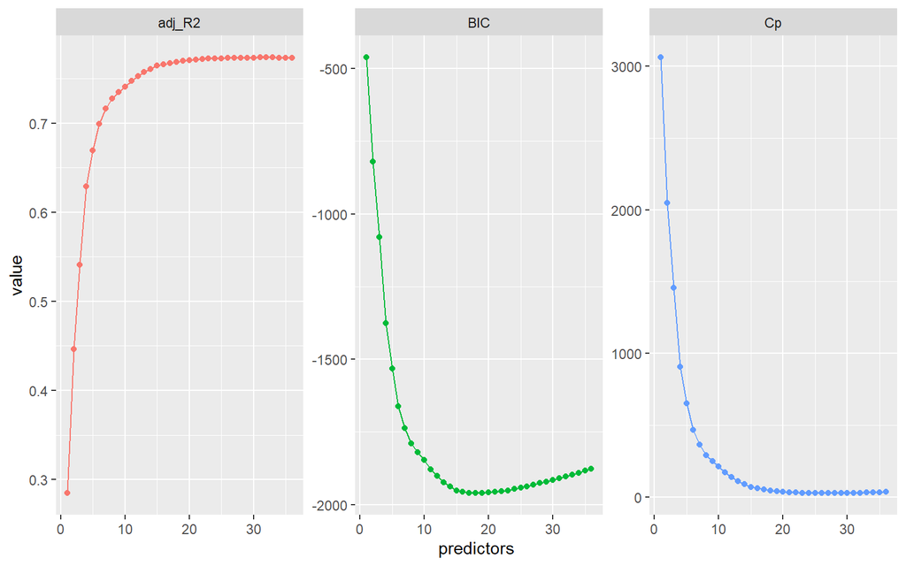

```r
results <- summary(best_subset_WG2)

# Extrahieren und plotten der Ergebnisse
tibble(predictors = 1:36,
       adj_R2 = results$adjr2,
       Cp = results$cp,
       BIC = results$bic) %>%
  gather(statistic, value, -predictors) %>%
  ggplot(aes(predictors, value, color = statistic)) +
  geom_line(show.legend = F) +
  geom_point(show.legend = F) +
  facet_wrap(~ statistic, scales = "free")
```

```r
which.max(results$adjr2)
```

```
## [1] 32
```

```r
which.min(results$bic)
```

```
## [1] 19
```

```r
which.min(results$cp)
```

```
## [1] 27
```

Die Variablen und Koeffizienten, die diese Modelle enthalten, können mittels der `coef`-Funktion verglichen werden:

Der gleiche Prozess kann durch schrittweise Vorwärts- und Rückwärtsauswahl durchgeführt werden, um noch mehr Optionen für optimale Modelle zu erhalten:

```r
forward <- regsubsets(Umsatz ~ ., df_lm_train_WG2, nvmax = 36, method = "forward")
backward <- regsubsets(Umsatz ~ ., df_lm_train_WG2, nvmax = 36, method = "backward")

# Welches Modell minimiert den Cp?
which.min(summary(forward)$cp)
```

```
## [1] 31
```

```r
which.min(summary(backward)$cp)
```

```
## [1] 30
```

Wenn man das optimale $C_p$ für vorwärts und rückwärts schrittweise bewertet, ist erkennbar, dass gemäß der Vorwärts-Methode ein 31-Variablen-Modell die $C_p$-Statistik minimiert. Die Rückwärtsmethode schlägt ein 30-Variablen-Modell vor.

Wenn wir diese Modelle bewerten, ergibt sich bzgl. der Zusammensetzung der Prädikatoren-Stes folgendes Bild:.

```r
# 19-Variablen-Modell
coef(best_subset_WG2, 19)
```

```
##            (Intercept)            KielerWoche             Temperatur
##             289.670164             114.755085               3.600748
##     Wochentag_cFreitag     Wochentag_cSamstag     Wochentag_cSonntag
##              16.387490             116.592843             173.747069
##         Monat_cFebruar          Monat_cJanuar            Monat_cMärz
##             -22.100382             -32.805725             -34.469215
##         Monat_cOktober         SommerferienSH        SommerferienNRW
##              73.884630              53.595044              91.667246
##        SommerferienNDS         SommerferienHE               Feiertag
##              35.696146              52.963997              85.242085
##             Ostern_ext ChristiHimmelfahrt_ext          Pfingsten_ext
##             190.112727              88.877808              82.507410
##          Silvester_ext       JahreszeitHerbst
##             161.447644             -45.983222
```

```r
# 27-Variablen-Modell
coef(best_subset_WG2, 27)
```

```
##            (Intercept)            KielerWoche             Bewoelkung
##            300.4426300            106.4081526             -1.9944071
##             Temperatur    Windgeschwindigkeit     Wochentag_cFreitag
##              2.2458640              0.6731218             14.7321877
##    Wochentag_cMittwoch     Wochentag_cSamstag     Wochentag_cSonntag
##             -7.3828287            114.3262895            172.0672918
##          Monat_cAugust         Monat_cFebruar          Monat_cJanuar
##             31.1385438            -21.1880439            -33.8672705
##            Monat_cJuli            Monat_cJuni            Monat_cMärz
##             31.2779417             27.9457291            -31.2614621
##         Monat_cOktober       Monat_cSeptember         SommerferienSH
##             82.4987784             23.9082216             50.1380316
##        SommerferienNRW        SommerferienNDS         SommerferienHE
##             85.2740232             30.9085069             51.9845646
##               Feiertag                 Ostern             Ostern_ext
##            101.1324749            -74.4678250            222.6716868
## ChristiHimmelfahrt_ext          Pfingsten_ext          Silvester_ext
##             95.2641385             73.8723795            157.9220733
##       JahreszeitHerbst
##            -43.1588521
```

```r
# 32-Variablen-Modell
coef(best_subset_WG2, 32)
```

```
##            (Intercept)            KielerWoche             Bewoelkung
##            293.0827010            117.9578507             -1.9346214
##             Temperatur    Windgeschwindigkeit     Wochentag_cFreitag
##              2.4993246              0.6804694             14.6799796
##    Wochentag_cMittwoch     Wochentag_cSamstag     Wochentag_cSonntag
##             -7.1008732            114.3486987            172.0861877
##          Monat_cAugust        Monat_cDezember          Monat_cJanuar
##             51.7469927             33.5152883            -13.5854712
##            Monat_cJuli            Monat_cJuni            Monat_cMärz
##             50.2015847             32.5389107            -17.6541448
##        Monat_cNovember         Monat_cOktober       Monat_cSeptember
##             37.2779931            114.7756775             48.0435134
##         SommerferienSH        SommerferienNRW        SommerferienNDS
##             49.4695160             86.7619540             34.0360619
##         SommerferienHE               Feiertag     ChristiHimmelfahrt
##             49.5138317             28.5135372             85.9076430
##              Pfingsten                    TDE             Ostern_ext
##             79.6428657             88.6400121            223.5391977
## ChristiHimmelfahrt_ext          Pfingsten_ext          Silvester_ext
##             95.3051638             70.9997316            180.2951038
##       JahreszeitHerbst       JahreszeitSommer       JahreszeitWinter
##            -72.2568178            -18.7856521            -13.9938689
```

```r
coef(forward, 31)
```

```
##            (Intercept)            KielerWoche             Bewoelkung
##             292.765074             114.260852              -2.015801
##             Temperatur    Windgeschwindigkeit     Wochentag_cFreitag
##               2.327146               0.673390              14.801048
##    Wochentag_cMittwoch     Wochentag_cSamstag     Wochentag_cSonntag
##              -7.329412             114.218439             171.927158
##          Monat_cAugust        Monat_cDezember         Monat_cFebruar
##              50.019613              24.969686             -13.748135
##          Monat_cJanuar            Monat_cJuli            Monat_cJuni
##             -26.236367              49.120786              35.950175
##             Monat_cMai            Monat_cMärz        Monat_cNovember
##               7.729174             -24.253729              30.173179
##         Monat_cOktober       Monat_cSeptember         SommerferienSH
##             109.090498              45.033733              49.753894
##        SommerferienNRW        SommerferienNDS         SommerferienHE
##              86.322642              33.050139              50.300003
##               Feiertag                 Ostern             Ostern_ext
##             101.087580             -75.156591             228.703658
## ChristiHimmelfahrt_ext          Pfingsten_ext          Silvester_ext
##              93.973494              72.549792             140.420486
##       JahreszeitHerbst       JahreszeitSommer
##             -62.975529             -12.896948
```

```r
coef(backward, 30)
```

```
##            (Intercept)            KielerWoche             Bewoelkung
##            291.1000866            117.9055938             -1.8890962
##             Temperatur    Windgeschwindigkeit     Wochentag_cFreitag
##              2.5185703              0.6569262             16.4305003
##     Wochentag_cSamstag     Wochentag_cSonntag          Monat_cAugust
##            115.8533768            174.2325499             51.3109994
##        Monat_cDezember          Monat_cJanuar            Monat_cJuli
##             33.5326738            -13.4151407             49.6403076
##            Monat_cJuni            Monat_cMärz        Monat_cNovember
##             32.4225440            -17.4933789             37.2659441
##         Monat_cOktober       Monat_cSeptember         SommerferienSH
##            114.6604583             47.9379579             49.4453514
##        SommerferienNRW        SommerferienNDS         SommerferienHE
##             87.1796710             34.1141032             49.4758872
##     ChristiHimmelfahrt              Pfingsten                    TDE
##            117.5452725            107.8945339            118.1724318
##             Ostern_ext ChristiHimmelfahrt_ext          Pfingsten_ext
##            239.6808168             94.0255530             72.0089146
##          Silvester_ext       JahreszeitHerbst       JahreszeitSommer
##            193.7338412            -72.2121158            -18.7581004
##       JahreszeitWinter
##            -13.9848360
```

### Direkte Schätzung des Testfehlers

Nun wird der Fehler der Testdaten für das beste Modell jeder Modellgröße berechnet. Zuerst wird eine Modellmatrix aus den Testdaten erstellt. Die Funktion `model.matrix` wird in vielen Regressionspaketen zum Erstellen einer X-Matrix aus Daten verwendet.

```r
test_m <- model.matrix(Umsatz ~ ., data = df_lm_test_WG2)
```

```r
# Erstellen eines leeren Vektors, um diesen nachfolgend mit den Fehlerwerten zu füllen
validation_errors <- vector("double", length = 36)

for(i in 1:36) {
  coef_x <- coef(best_subset_WG2, id = i)                     # extract coefficients for model size i
  pred_x <- test_m[ , names(coef_x)] %*% coef_x           # predict salary using matrix algebra
  validation_errors[i] <- mean((df_lm_test_WG2$Umsatz - pred_x)^2)  # compute test error btwn actual & predicted salary
}

as.matrix(validation_errors)
```

```
##            [,1]
##  [1,] 10309.836
##  [2,]  8312.558
##  [3,]  6592.104
##  [4,]  5257.919
##  [5,]  4747.595
##  [6,]  4326.941
##  [7,]  4056.363
##  [8,]  3973.651
##  [9,]  3855.485
## [10,]  3904.029
## [11,]  3774.393
## [12,]  3658.855
## [13,]  3398.222
## [14,]  3345.696
```

[output cut: 22 more lines]

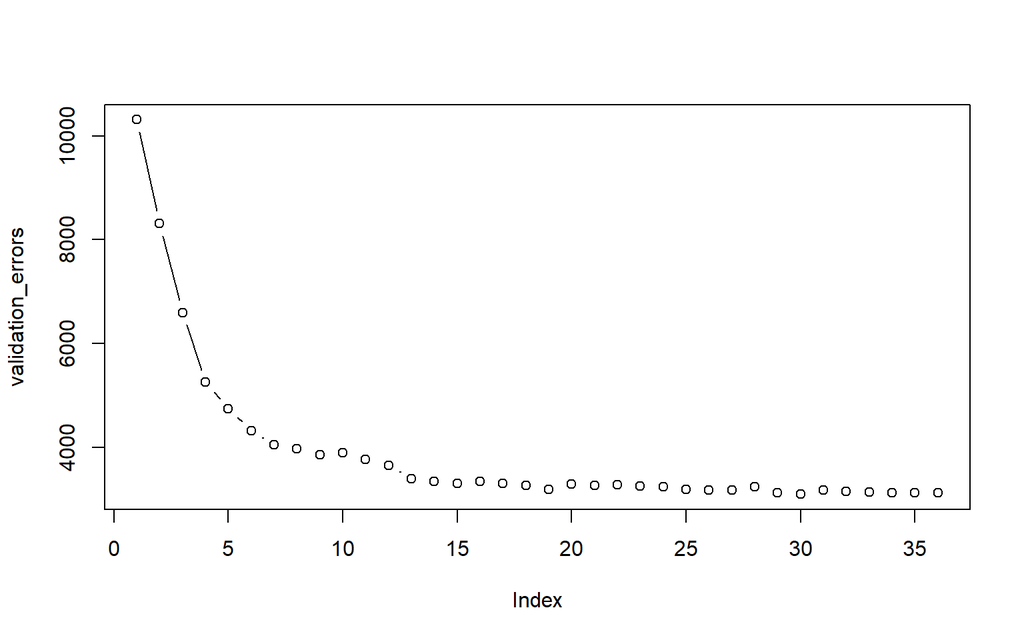

```r
# Plotten der validation errors
plot(validation_errors, type = "b")
```

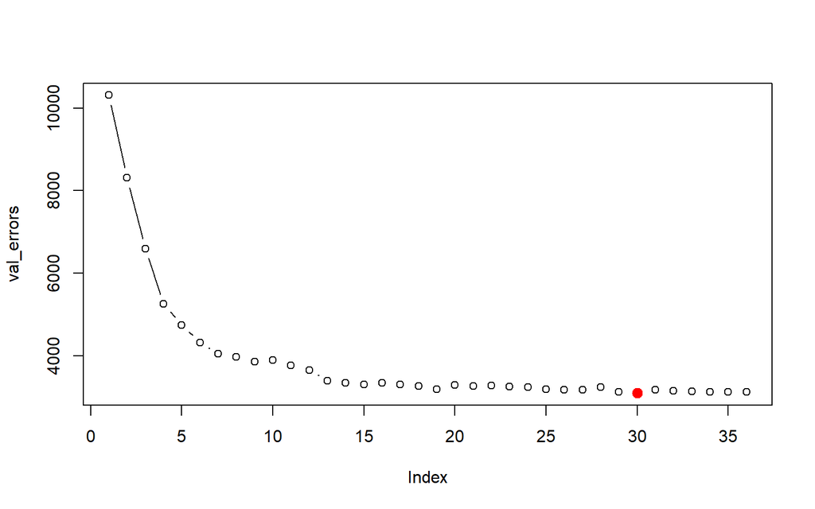

```r
#############################
# Alternative: http://www.science.smith.edu/~jcrouser/SDS293/labs/lab9-r.html
val_errors = rep(NA,36)

# Iterationen über jede Größe i
for(i in 1:36){

    # Extrahieren des Vektors der Prädiktoren im Best-Fit-Modell für i-Prädiktoren
    coefi = coef(best_subset_WG2, id = i)

    # Vorhersagen unter Verwendung der Matrixmultiplikation der Testmatrix und des Koeffizientenvektors erstellen
    pred = test_m[,names(coefi)]%*%coefi

    # Berechnung des MSE
    val_errors[i] = mean((df_lm_test_WG2$Umsatz-pred)^2)
}

# Auffinden des Modells mit dem kleinsten Fehler
min = which.min(val_errors)

# Plotten des Fehlers für jede Modellgröße
plot(val_errors, type = 'b')
points(min, val_errors[min][1], col = "red", cex = 2, pch = 20)
```

Es ist erkennbar, dass das 30-Variablen-Modell, das durch den besten Teilmengenansatz erzeugt wird, den niedrigsten Test-MSE erzeugt. Auch ein 29- sowie 36-Variablen-Modell scheinen vergleichweichsweise gut zu performen.

Wir können jetzt die beste Teilmengenauswahl für den gesamten Datensatz durchführen, um zum einen das 30-Variablen-Modell zu erhalten. Dieses Modell wird mit dem 19-und dem 29-Variablen-Modell verglichen.

**Teilmengenauswahl für das 30-Variablen-Modell**

```r
final_best_WG2_30 <- regsubsets(Umsatz ~ ., data = df_lm_train_WG2, nvmax = 36)
coef(final_best_WG2_30, 30)
```

```
##            (Intercept)            KielerWoche             Bewoelkung
##             293.547985             118.085019              -1.950524
##             Temperatur    Windgeschwindigkeit     Wochentag_cFreitag
##               2.488547               0.665880              14.757750
##    Wochentag_cMittwoch     Wochentag_cSamstag     Wochentag_cSonntag
##              -7.275431             114.135925             171.819049
##          Monat_cAugust        Monat_cDezember          Monat_cJanuar
##              51.877147              33.538279             -13.615677
##            Monat_cJuli            Monat_cJuni            Monat_cMärz
##              50.333570              32.531345             -17.647320
##        Monat_cNovember         Monat_cOktober       Monat_cSeptember
##              37.310589             115.402083              48.122208
##         SommerferienSH        SommerferienNRW        SommerferienNDS
##              49.458657              86.762657              34.066516
##         SommerferienHE               Feiertag                 Ostern
##              49.460584             101.094265             -75.915539
##             Ostern_ext ChristiHimmelfahrt_ext          Pfingsten_ext
##             225.344716              98.028610              74.589843
##          Silvester_ext       JahreszeitHerbst       JahreszeitSommer
##             144.029191             -72.358801             -18.831174
##       JahreszeitWinter
##             -14.068113
```

Die 30 Variablen sind die folgenden:

- KielerWoche
- Bewoelkung
- Temperatur
- Windgeschwindigkeit
- Wochentag_cFreitag
- Wochentag_cMittwoch
- Wochentag_cSamstag
- Wochentag_cSonntag
- Monat_cAugust
- Monat_cDezember
- Monat_cJanuar
- Monat_cJuli
- Monat_cJuni
- Monat_cMärz
- Monat_cNovember
- Monat_cOktober
- Monat_cSeptember
- SommerferienSH
- SommerferienNRW
- SommerferienNDS
- SommerferienHE
- Feiertag
- Ostern
- Ostern_ext
- ChristiHimmelfahrt_ext
- Pfingsten_ext
- Silvester_ext
- JahreszeitHerbst
- JahreszeitSommer
- JahreszeitWinter

Die Variablen Wochentag_c, Monat und Jahreszeit nun noch dummyfiziert werden (bei Einbeziehung aller Variablen erfolgt die Dummyfizierung automatisch im Rahmen der Regressionsanalyse): Für jeden Wochentag wird eine Variable mit Ausprägung 0/1 gebildet und danach die alte Variable Wochentag_c entfernt. Analog wird bei den beiden anderen Variablen vorgegangen.

```r
# Dummyfizierung der Variablen im Trainigsdatensatz:
df_lm_train_WG2_30 <- df_lm_train_WG2 %>%
  mutate(Montag=as.integer(df_lm_train_WG2$Wochentag_c=="Montag")) %>%
  mutate(Dienstag=as.integer(df_lm_train_WG2$Wochentag_c=="Dienstag")) %>%
  mutate(Mittwoch=as.integer(df_lm_train_WG2$Wochentag_c=="Mittwoch")) %>%
  mutate(Donnerstag=as.integer(df_lm_train_WG2$Wochentag_c=="Donnerstag")) %>%
  mutate(Freitag=as.integer(df_lm_train_WG2$Wochentag_c=="Freitag")) %>%
  mutate(Samstag=as.integer(df_lm_train_WG2$Wochentag_c=="Samstag")) %>%
  mutate(Sonntag=as.integer(df_lm_train_WG2$Wochentag_c=="Sonntag")) %>%
  mutate(Januar=as.integer(df_lm_train_WG2$Monat_c=="Januar")) %>%
  mutate(Februar=as.integer(df_lm_train_WG2$Monat_c=="Februar")) %>%
  mutate(Maerz=as.integer(df_lm_train_WG2$Monat_c=="März")) %>%
  mutate(April=as.integer(df_lm_train_WG2$Monat_c=="April")) %>%
  mutate(Mai=as.integer(df_lm_train_WG2$Monat_c=="Mai")) %>%
  mutate(Juni=as.integer(df_lm_train_WG2$Monat_c=="Juni")) %>%
  mutate(Juli=as.integer(df_lm_train_WG2$Monat_c=="Juli")) %>%
  mutate(August=as.integer(df_lm_train_WG2$Monat_c=="August")) %>%
  mutate(September=as.integer(df_lm_train_WG2$Monat_c=="September")) %>%
  mutate(Oktober=as.integer(df_lm_train_WG2$Monat_c=="Oktober")) %>%
  mutate(November=as.integer(df_lm_train_WG2$Monat_c=="November")) %>%
  mutate(Dezember=as.integer(df_lm_train_WG2$Monat_c=="Dezember")) %>%
  mutate(Fruehling=as.integer(df_lm_train_WG2$Jahreszeit=="Fruehling")) %>%
  mutate(Sommer=as.integer(df_lm_train_WG2$Jahreszeit=="Sommer")) %>%
  mutate(Herbst=as.integer(df_lm_train_WG2$Jahreszeit=="Herbst")) %>%
  mutate(Winter=as.integer(df_lm_train_WG2$Jahreszeit=="Winter")) %>%
  dplyr::select(-Wochentag_c, -Monat_c, -Jahreszeit)

df_lm_test_WG2_30 <- df_lm_test_WG2 %>%
  mutate(Montag=as.integer(df_lm_test_WG2$Wochentag_c=="Montag")) %>%
  mutate(Dienstag=as.integer(df_lm_test_WG2$Wochentag_c=="Dienstag")) %>%
  mutate(Mittwoch=as.integer(df_lm_test_WG2$Wochentag_c=="Mittwoch")) %>%
  mutate(Donnerstag=as.integer(df_lm_test_WG2$Wochentag_c=="Donnerstag")) %>%
  mutate(Freitag=as.integer(df_lm_test_WG2$Wochentag_c=="Freitag")) %>%
  mutate(Samstag=as.integer(df_lm_test_WG2$Wochentag_c=="Samstag")) %>%
  mutate(Sonntag=as.integer(df_lm_test_WG2$Wochentag_c=="Sonntag")) %>%
  mutate(Januar=as.integer(df_lm_test_WG2$Monat_c=="Januar")) %>%
  mutate(Februar=as.integer(df_lm_test_WG2$Monat_c=="Februar")) %>%
  mutate(Maerz=as.integer(df_lm_test_WG2$Monat_c=="März")) %>%
  mutate(April=as.integer(df_lm_test_WG2$Monat_c=="April")) %>%
  mutate(Mai=as.integer(df_lm_test_WG2$Monat_c=="Mai")) %>%
  mutate(Juni=as.integer(df_lm_test_WG2$Monat_c=="Juni")) %>%
  mutate(Juli=as.integer(df_lm_test_WG2$Monat_c=="Juli")) %>%
  mutate(August=as.integer(df_lm_test_WG2$Monat_c=="August")) %>%
  mutate(September=as.integer(df_lm_test_WG2$Monat_c=="September")) %>%
  mutate(Oktober=as.integer(df_lm_test_WG2$Monat_c=="Oktober")) %>%
  mutate(November=as.integer(df_lm_test_WG2$Monat_c=="November")) %>%
  mutate(Dezember=as.integer(df_lm_test_WG2$Monat_c=="Dezember")) %>%
  mutate(Fruehling=as.integer(df_lm_test_WG2$Jahreszeit=="Fruehling")) %>%
  mutate(Sommer=as.integer(df_lm_test_WG2$Jahreszeit=="Sommer")) %>%
  mutate(Herbst=as.integer(df_lm_test_WG2$Jahreszeit=="Herbst")) %>%
  mutate(Winter=as.integer(df_lm_test_WG2$Jahreszeit=="Winter")) %>%
  dplyr::select(-Wochentag_c, -Monat_c, -Jahreszeit)
```

Für das 30-Variablenmodell wird nun ein Regressionsmodell erstellt:

```r
lm_WG2_30_train <- lm(Umsatz ~ KielerWoche + Bewoelkung + Temperatur + Windgeschwindigkeit + Freitag + Mittwoch + Samstag + Sonntag + August +  Dezember + Januar + Juli + Juni + Maerz + November + Oktober + September + SommerferienSH + SommerferienNRW + SommerferienNDS + SommerferienHE + Feiertag + Ostern + Ostern_ext + ChristiHimmelfahrt_ext + Silvester_ext + Herbst + Sommer + Winter, data = df_lm_train_WG2_30)

glance(lm_WG2_30_train)
```

```
## # A tibble: 1 x 11
##   r.squared adj.r.squared sigma statistic p.value    df logLik    AIC
##       <dbl>         <dbl> <dbl>     <dbl>   <dbl> <int>  <dbl>  <dbl>
## 1     0.776         0.771  64.2      166.       0    30 -7910. 15881.
## # ... with 3 more variables: BIC <dbl>, deviance <dbl>, df.residual <int>
```

Dann wird (die Modellgüte) anhand der *Test*-Stichprobe getestet:

```r
lm_WG2_30_predict <- predict(lm_WG2_30_train, newdata = df_lm_test_WG2_30)
```

Als Ergebnis wird ein Vektor erzeugt, der für jede Beobachtung des Test-Samples den geschätzten (vorhergesagten) Umsatzwert speichert. Die Gütewerte lassen sich mit `caret::postResample` ausgeben:

```r
caret::postResample(pred = lm_WG2_30_predict, obs = df_lm_test_WG2_30$Umsatz)
```

```
##       RMSE   Rsquared        MAE
## 56.2258855  0.8475938 45.2566413
```

Diese Vorhersage-Ergebnisse werden den Test-Daten hinzugefügt, sodann die Gütekennzahlen berechnet, die wiederum der gemeinsamen Übersichtstabelle für die Gütekennzahlen `lm_vgl_kennz` hinzugefügt werden:

```r
# Hinzufügen der Ergebnisse
df_lm_test_WG2_30 <- df_lm_test_WG2_30 %>%
  mutate(predicted = lm_WG2_30_predict)

# ergänze Prognose_zuhoch (TRUE / FALSE), Abweichung (Schätzer - Umsatz), absolute Abweichung (Abweichung_abs), relative Abweichung (Abweichung_rel), quadratische Abweichung (Abweichung_quad)
df_lm_test_WG2_30 <- df_lm_test_WG2_30 %>%
  mutate(Prognose_zuhoch = (predicted >= Umsatz)) %>%
  mutate(Abweichung = predicted - Umsatz) %>%
  mutate(Abweichung_abs = abs(predicted - Umsatz)) %>%
  mutate(Abweichung_rel = (predicted - Umsatz) / Umsatz) %>%
  mutate(Abweichung_quad = Abweichung^2)

# Ergänze die benötigten Hilfsgrößen
df_lm_test_WG2_30 <-df_lm_test_WG2_30 %>%
  mutate(Abweichung_rel_abs = abs(Abweichung_rel), Abweichung_rel_abs_mult_umsatz = Abweichung_rel_abs * Umsatz)

# Prognosegüte: mittlere Abweichung, mittlere absolute / relative Abweichung, mittlere quadratische Abweichung
temp <- df_lm_test_WG2_30 %>%
  group_by() %>%
  summarise(Anzahl=n(), Umsatz_ges = round(sum(Umsatz)), Umsatz_mittel = round(sum(Umsatz)/n()), MAE = round(mean(Abweichung_abs)), MPE = round(mean(Abweichung_rel)*100), MAPE = round(mean(Abweichung_rel_abs)*100), WAPE = round(sum(Abweichung_rel_abs_mult_umsatz)/sum(Umsatz)*100), MSE = round(mean(Abweichung_quad)), RMSE = round(sqrt(mean(Abweichung_quad))))

# füge das Modell hinzu
temp <- temp %>% mutate(Modell = "best30_WG2")

# füge die Kennzahlen nun an die Vergleichstabelle
lm_vgl_kennz <- rbind(lm_vgl_kennz, temp)
lm_vgl_kennz
```

```
## # A tibble: 3 x 10
##   Anzahl Umsatz_ges Umsatz_mittel   MAE   MPE  MAPE  WAPE   MSE  RMSE
##    <int>      <dbl>         <dbl> <dbl> <dbl> <dbl> <dbl> <dbl> <dbl>
## 1    346      45738           132    23    -4    18    18   965    31
## 2    346      45738           132    23    -4    18    18   949    31
## 3    346     130413           377    45     9    13    12  3161    56
## # ... with 1 more variable: Modell <chr>
```

**Teilmengenauswahl für das 29-Variablen-Modell**

```r
final_best_WG2_29 <- regsubsets(Umsatz ~ ., data = df_lm_train_WG2, nvmax = 36)
coef(final_best_WG2_29, 29)
```

```
##            (Intercept)            KielerWoche             Bewoelkung
##            294.6935059            106.5571748             -1.9875605
##             Temperatur    Windgeschwindigkeit     Wochentag_cFreitag
##              2.4480401              0.6757591             14.8360286
##    Wochentag_cMittwoch     Wochentag_cSamstag     Wochentag_cSonntag
##             -7.3650515            114.3795555            172.0025280
##          Monat_cAugust        Monat_cDezember         Monat_cFebruar
##             33.8656965             16.7438107            -16.4454150
##          Monat_cJanuar            Monat_cJuli            Monat_cJuni
##            -28.6803937             33.4206257             29.7671350
##            Monat_cMärz        Monat_cNovember         Monat_cOktober
##            -27.2694765             19.9690671             98.2589764
##       Monat_cSeptember         SommerferienSH        SommerferienNRW
##             29.6820946             49.4735607             85.1950405
##        SommerferienNDS         SommerferienHE               Feiertag
##             30.6063174             51.6387981            101.0754763
##                 Ostern             Ostern_ext ChristiHimmelfahrt_ext
##            -74.7726912            225.8105656             97.5796679
##          Pfingsten_ext          Silvester_ext       JahreszeitHerbst
##             75.4327216            145.8808435            -55.8155927
```

Die 29 Variablen sind die folgenden:

- KielerWoche
- Bewoelkung
- Temperatur
- Windgeschwindigkeit
- Wochentag_cFreitag
- Wochentag_cMittwoch
- Wochentag_cSamstag
- Wochentag_cSonntag
- Monat_cAugust
- Monat_cDezember
- Monat_cFebruar
- Monat_cJanuar
- Monat_cJuli
- Monat_cJuni
- Monat_cMärz
- Monat_cNovember
- Monat_cOktober
- Monat_cSeptember
- SommerferienSH
- SommerferienNRW
- SommerferienNDS
- SommerferienHE
- Feiertag
- Ostern
- Ostern_ext
- ChristiHimmelfahrt_ext
- Pfingsten_ext
- Silvester_ext
- JahreszeitHerbst

Es fehlen: Sommer, Winter; es kommt hinzu Februar (= -2+1 ==> 29)

Die Variablen Wochentag_c, Monat und Jahreszeit nun noch dummyfiziert werden (bei Einbeziehung aller Variablen erfolgt die Dummyfizierung automatisch im Rahmen der Regressionsanalyse): Für jeden Wochentag wird eine Variable mit Ausprägung 0/1 gebildet und danach die alte Variable Wochentag_c entfernt. Analog wird bei den beiden anderen Variablen vorgegangen.

```r
# Dummyfizierung der Variablen im Trainigsdatensatz:
df_lm_train_WG2_29 <- df_lm_train_WG2 %>%
  mutate(Montag=as.integer(df_lm_train_WG2$Wochentag_c=="Montag")) %>%
  mutate(Dienstag=as.integer(df_lm_train_WG2$Wochentag_c=="Dienstag")) %>%
  mutate(Mittwoch=as.integer(df_lm_train_WG2$Wochentag_c=="Mittwoch")) %>%
  mutate(Donnerstag=as.integer(df_lm_train_WG2$Wochentag_c=="Donnerstag")) %>%
  mutate(Freitag=as.integer(df_lm_train_WG2$Wochentag_c=="Freitag")) %>%
  mutate(Samstag=as.integer(df_lm_train_WG2$Wochentag_c=="Samstag")) %>%
  mutate(Sonntag=as.integer(df_lm_train_WG2$Wochentag_c=="Sonntag")) %>%
  mutate(Januar=as.integer(df_lm_train_WG2$Monat_c=="Januar")) %>%
  mutate(Februar=as.integer(df_lm_train_WG2$Monat_c=="Februar")) %>%
  mutate(Maerz=as.integer(df_lm_train_WG2$Monat_c=="März")) %>%
  mutate(April=as.integer(df_lm_train_WG2$Monat_c=="April")) %>%
  mutate(Mai=as.integer(df_lm_train_WG2$Monat_c=="Mai")) %>%
  mutate(Juni=as.integer(df_lm_train_WG2$Monat_c=="Juni")) %>%
  mutate(Juli=as.integer(df_lm_train_WG2$Monat_c=="Juli")) %>%
  mutate(August=as.integer(df_lm_train_WG2$Monat_c=="August")) %>%
  mutate(September=as.integer(df_lm_train_WG2$Monat_c=="September")) %>%
  mutate(Oktober=as.integer(df_lm_train_WG2$Monat_c=="Oktober")) %>%
  mutate(November=as.integer(df_lm_train_WG2$Monat_c=="November")) %>%
  mutate(Dezember=as.integer(df_lm_train_WG2$Monat_c=="Dezember")) %>%
  mutate(Fruehling=as.integer(df_lm_train_WG2$Jahreszeit=="Fruehling")) %>%
  mutate(Sommer=as.integer(df_lm_train_WG2$Jahreszeit=="Sommer")) %>%
  mutate(Herbst=as.integer(df_lm_train_WG2$Jahreszeit=="Herbst")) %>%
  mutate(Winter=as.integer(df_lm_train_WG2$Jahreszeit=="Winter")) %>%
  dplyr::select(-Wochentag_c, -Monat_c, -Jahreszeit)

df_lm_test_WG2_29 <- df_lm_test_WG2 %>%
  mutate(Montag=as.integer(df_lm_test_WG2$Wochentag_c=="Montag")) %>%
  mutate(Dienstag=as.integer(df_lm_test_WG2$Wochentag_c=="Dienstag")) %>%
  mutate(Mittwoch=as.integer(df_lm_test_WG2$Wochentag_c=="Mittwoch")) %>%
  mutate(Donnerstag=as.integer(df_lm_test_WG2$Wochentag_c=="Donnerstag")) %>%
  mutate(Freitag=as.integer(df_lm_test_WG2$Wochentag_c=="Freitag")) %>%
  mutate(Samstag=as.integer(df_lm_test_WG2$Wochentag_c=="Samstag")) %>%
  mutate(Sonntag=as.integer(df_lm_test_WG2$Wochentag_c=="Sonntag")) %>%
  mutate(Januar=as.integer(df_lm_test_WG2$Monat_c=="Januar")) %>%
  mutate(Februar=as.integer(df_lm_test_WG2$Monat_c=="Februar")) %>%
  mutate(Maerz=as.integer(df_lm_test_WG2$Monat_c=="März")) %>%
  mutate(April=as.integer(df_lm_test_WG2$Monat_c=="April")) %>%
  mutate(Mai=as.integer(df_lm_test_WG2$Monat_c=="Mai")) %>%
  mutate(Juni=as.integer(df_lm_test_WG2$Monat_c=="Juni")) %>%
  mutate(Juli=as.integer(df_lm_test_WG2$Monat_c=="Juli")) %>%
  mutate(August=as.integer(df_lm_test_WG2$Monat_c=="August")) %>%
  mutate(September=as.integer(df_lm_test_WG2$Monat_c=="September")) %>%
  mutate(Oktober=as.integer(df_lm_test_WG2$Monat_c=="Oktober")) %>%
  mutate(November=as.integer(df_lm_test_WG2$Monat_c=="November")) %>%
  mutate(Dezember=as.integer(df_lm_test_WG2$Monat_c=="Dezember")) %>%
  mutate(Fruehling=as.integer(df_lm_test_WG2$Jahreszeit=="Fruehling")) %>%
  mutate(Sommer=as.integer(df_lm_test_WG2$Jahreszeit=="Sommer")) %>%
  mutate(Herbst=as.integer(df_lm_test_WG2$Jahreszeit=="Herbst")) %>%
  mutate(Winter=as.integer(df_lm_test_WG2$Jahreszeit=="Winter")) %>%
  dplyr::select(-Wochentag_c, -Monat_c, -Jahreszeit)
```

Für das 29-Variablenmodell wird nun ein Regressionsmodell erstellt:

```r
lm_WG2_29_train <- lm(Umsatz ~ KielerWoche + Bewoelkung + Temperatur + Windgeschwindigkeit + Freitag + Mittwoch + Samstag + Sonntag + August +  Dezember + Januar + Februar + Juli + Juni + Maerz + November + Oktober + September + SommerferienSH + SommerferienNRW + SommerferienNDS + SommerferienHE + Feiertag + Ostern + Ostern_ext + ChristiHimmelfahrt_ext + Silvester_ext + Herbst, data = df_lm_train_WG2_29)

glance(lm_WG2_29_train)
```

```
## # A tibble: 1 x 11
##   r.squared adj.r.squared sigma statistic p.value    df logLik    AIC
##       <dbl>         <dbl> <dbl>     <dbl>   <dbl> <int>  <dbl>  <dbl>
## 1     0.776         0.771  64.2      172.       0    29 -7911. 15881.
## # ... with 3 more variables: BIC <dbl>, deviance <dbl>, df.residual <int>
```

Dann wird (die Modellgüte) anhand der *Test*-Stichprobe getestet:

```r
lm_WG2_29_predict <- predict(lm_WG2_29_train, newdata = df_lm_test_WG2_29)
```

Als Ergebnis wird ein Vektor erzeugt, der für jede Beobachtung des Test-Samples den geschätzten (vorhergesagten) Umsatzwert speichert. Die Gütewerte lassen sich mit `caret::postResample` ausgeben:

```r
caret::postResample(pred = lm_WG2_29_predict, obs = df_lm_test_WG2_29$Umsatz)
```

```
##       RMSE   Rsquared        MAE
## 56.4723843  0.8458877 45.4639878
```

Diese Vorhersage-Ergebnisse werden den Test-Daten hinzugefügt, sodann die Gütekennzahlen berechnet, die wiederum der gemeinsamen Übersichtstabelle für die Gütekennzahlen `lm_vgl_kennz` hinzugefügt werden:

```r
# Hinzufügen der Ergebnisse
df_lm_test_WG2_29 <- df_lm_test_WG2_29 %>%
  mutate(predicted = lm_WG2_29_predict)

# ergänze Prognose_zuhoch (TRUE / FALSE), Abweichung (Schätzer - Umsatz), absolute Abweichung (Abweichung_abs), relative Abweichung (Abweichung_rel), quadratische Abweichung (Abweichung_quad)
df_lm_test_WG2_29 <- df_lm_test_WG2_29 %>%
  mutate(Prognose_zuhoch = (predicted >= Umsatz)) %>%
  mutate(Abweichung = predicted - Umsatz) %>%
  mutate(Abweichung_abs = abs(predicted - Umsatz)) %>%
  mutate(Abweichung_rel = (predicted - Umsatz) / Umsatz) %>%
  mutate(Abweichung_quad = Abweichung^2)

# Ergänze die benötigten Hilfsgrößen
df_lm_test_WG2_29 <-df_lm_test_WG2_29 %>%
  mutate(Abweichung_rel_abs = abs(Abweichung_rel), Abweichung_rel_abs_mult_umsatz = Abweichung_rel_abs * Umsatz)

# Prognosegüte: mittlere Abweichung, mittlere absolute / relative Abweichung, mittlere quadratische Abweichung
temp <- df_lm_test_WG2_29 %>%
  group_by() %>%
  summarise(Anzahl=n(), Umsatz_ges = round(sum(Umsatz)), Umsatz_mittel = round(sum(Umsatz)/n()), MAE = round(mean(Abweichung_abs)), MPE = round(mean(Abweichung_rel)*100), MAPE = round(mean(Abweichung_rel_abs)*100), WAPE = round(sum(Abweichung_rel_abs_mult_umsatz)/sum(Umsatz)*100), MSE = round(mean(Abweichung_quad)), RMSE = round(sqrt(mean(Abweichung_quad))))

# füge das Modell hinzu
temp <- temp %>% mutate(Modell = "best29_WG2")

# füge die Kennzahlen nun an die Vergleichstabelle
lm_vgl_kennz <- rbind(lm_vgl_kennz, temp)
lm_vgl_kennz
```

```
## # A tibble: 4 x 10
##   Anzahl Umsatz_ges Umsatz_mittel   MAE   MPE  MAPE  WAPE   MSE  RMSE
##    <int>      <dbl>         <dbl> <dbl> <dbl> <dbl> <dbl> <dbl> <dbl>
## 1    346      45738           132    23    -4    18    18   965    31
## 2    346      45738           132    23    -4    18    18   949    31
## 3    346     130413           377    45     9    13    12  3161    56
## 4    346     130413           377    45     9    13    12  3189    56
## # ... with 1 more variable: Modell <chr>
```

**Teilmengenauswahl für das 19-Variablen-Modell**

```r
final_best_WG2_19 <- regsubsets(Umsatz ~ ., data = df_lm_train_WG2, nvmax = 36)
coef(final_best_WG2_19, 19)
```

```
##            (Intercept)            KielerWoche             Temperatur
##             289.670164             114.755085               3.600748
##     Wochentag_cFreitag     Wochentag_cSamstag     Wochentag_cSonntag
##              16.387490             116.592843             173.747069
##         Monat_cFebruar          Monat_cJanuar            Monat_cMärz
##             -22.100382             -32.805725             -34.469215
##         Monat_cOktober         SommerferienSH        SommerferienNRW
##              73.884630              53.595044              91.667246
##        SommerferienNDS         SommerferienHE               Feiertag
##              35.696146              52.963997              85.242085
##             Ostern_ext ChristiHimmelfahrt_ext          Pfingsten_ext
##             190.112727              88.877808              82.507410
##          Silvester_ext       JahreszeitHerbst
##             161.447644             -45.983222
```

Die 19 Variablen sind die folgenden:

- KielerWoche
- Temperatur
- Wochentag_cFreitag
- Wochentag_cSamstag
- Wochentag_cSonntag
- Monat_cFebruar
- Monat_cJanuar
- Monat_cMärz
- Monat_cOktober
- SommerferienSH
- SommerferienNRW
- SommerferienNDS
- SommerferienHE
- Feiertag
- Ostern_ext
- ChristiHimmelfahrt_ext
- Pfingsten_ext
- Silvester_ext
- JahreszeitHerbst

Die Variablen Wochentag_c, Monat_c und Jahreszeit nun noch dummyfiziert werden (bei Einbeziehung aller Variablen erfolgt die Dummyfizierung automatisch im Rahmen der Regressionsanalyse): Für jeden Wochentag wird eine Variable mit Ausprägung 0/1 gebildet und danach die alte Variable Wochentag_c entfernt. Analog wird bei den beiden anderen Variablen vorgegangen.

```r
# Dummyfizierung der Variablen im Trainigsdatensatz:
df_lm_train_WG2_19 <- df_lm_train_WG2 %>%
  mutate(Montag=as.integer(df_lm_train_WG2$Wochentag_c=="Montag")) %>%
  mutate(Dienstag=as.integer(df_lm_train_WG2$Wochentag_c=="Dienstag")) %>%
  mutate(Mittwoch=as.integer(df_lm_train_WG2$Wochentag_c=="Mittwoch")) %>%
  mutate(Donnerstag=as.integer(df_lm_train_WG2$Wochentag_c=="Donnerstag")) %>%
  mutate(Freitag=as.integer(df_lm_train_WG2$Wochentag_c=="Freitag")) %>%
  mutate(Samstag=as.integer(df_lm_train_WG2$Wochentag_c=="Samstag")) %>%
  mutate(Sonntag=as.integer(df_lm_train_WG2$Wochentag_c=="Sonntag")) %>%
  mutate(Januar=as.integer(df_lm_train_WG2$Monat_c=="Januar")) %>%
  mutate(Februar=as.integer(df_lm_train_WG2$Monat_c=="Februar")) %>%
  mutate(Maerz=as.integer(df_lm_train_WG2$Monat_c=="März")) %>%
  mutate(April=as.integer(df_lm_train_WG2$Monat_c=="April")) %>%
  mutate(Mai=as.integer(df_lm_train_WG2$Monat_c=="Mai")) %>%
  mutate(Juni=as.integer(df_lm_train_WG2$Monat_c=="Juni")) %>%
  mutate(Juli=as.integer(df_lm_train_WG2$Monat_c=="Juli")) %>%
  mutate(August=as.integer(df_lm_train_WG2$Monat_c=="August")) %>%
  mutate(September=as.integer(df_lm_train_WG2$Monat_c=="September")) %>%
  mutate(Oktober=as.integer(df_lm_train_WG2$Monat_c=="Oktober")) %>%
  mutate(November=as.integer(df_lm_train_WG2$Monat_c=="November")) %>%
  mutate(Dezember=as.integer(df_lm_train_WG2$Monat_c=="Dezember")) %>%
  mutate(Fruehling=as.integer(df_lm_train_WG2$Jahreszeit=="Fruehling")) %>%
  mutate(Sommer=as.integer(df_lm_train_WG2$Jahreszeit=="Sommer")) %>%
  mutate(Herbst=as.integer(df_lm_train_WG2$Jahreszeit=="Herbst")) %>%
  mutate(Winter=as.integer(df_lm_train_WG2$Jahreszeit=="Winter")) %>%
  dplyr::select(-Wochentag_c, -Monat_c, -Jahreszeit)

df_lm_test_WG2_19 <- df_lm_test_WG2 %>%
  mutate(Montag=as.integer(df_lm_test_WG2$Wochentag_c=="Montag")) %>%
  mutate(Dienstag=as.integer(df_lm_test_WG2$Wochentag_c=="Dienstag")) %>%
  mutate(Mittwoch=as.integer(df_lm_test_WG2$Wochentag_c=="Mittwoch")) %>%
  mutate(Donnerstag=as.integer(df_lm_test_WG2$Wochentag_c=="Donnerstag")) %>%
  mutate(Freitag=as.integer(df_lm_test_WG2$Wochentag_c=="Freitag")) %>%
  mutate(Samstag=as.integer(df_lm_test_WG2$Wochentag_c=="Samstag")) %>%
  mutate(Sonntag=as.integer(df_lm_test_WG2$Wochentag_c=="Sonntag")) %>%
  mutate(Januar=as.integer(df_lm_test_WG2$Monat_c=="Januar")) %>%
  mutate(Februar=as.integer(df_lm_test_WG2$Monat_c=="Februar")) %>%
  mutate(Maerz=as.integer(df_lm_test_WG2$Monat_c=="März")) %>%
  mutate(April=as.integer(df_lm_test_WG2$Monat_c=="April")) %>%
  mutate(Mai=as.integer(df_lm_test_WG2$Monat_c=="Mai")) %>%
  mutate(Juni=as.integer(df_lm_test_WG2$Monat_c=="Juni")) %>%
  mutate(Juli=as.integer(df_lm_test_WG2$Monat_c=="Juli")) %>%
  mutate(August=as.integer(df_lm_test_WG2$Monat_c=="August")) %>%
  mutate(September=as.integer(df_lm_test_WG2$Monat_c=="September")) %>%
  mutate(Oktober=as.integer(df_lm_test_WG2$Monat_c=="Oktober")) %>%
  mutate(November=as.integer(df_lm_test_WG2$Monat_c=="November")) %>%
  mutate(Dezember=as.integer(df_lm_test_WG2$Monat_c=="Dezember")) %>%
  mutate(Fruehling=as.integer(df_lm_test_WG2$Jahreszeit=="Fruehling")) %>%
  mutate(Sommer=as.integer(df_lm_test_WG2$Jahreszeit=="Sommer")) %>%
  mutate(Herbst=as.integer(df_lm_test_WG2$Jahreszeit=="Herbst")) %>%
  mutate(Winter=as.integer(df_lm_test_WG2$Jahreszeit=="Winter")) %>%
  dplyr::select(-Wochentag_c, -Monat_c, -Jahreszeit)
```

- KielerWoche
- Temperatur
- Wochentag_cFreitag
- Wochentag_cSamstag
- Wochentag_cSonntag
- Monat_cFebruar
- Monat_cJanuar
- Monat_cMärz
- Monat_cOktober
- SommerferienSH
- SommerferienNRW
- SommerferienNDS
- SommerferienHE
- Feiertag
- Ostern_ext
- ChristiHimmelfahrt_ext
- Pfingsten_ext
- Silvester_ext
- JahreszeitHerbst

Für das 19-Variablenmodell wird nun ein Regressionsmodell erstellt:

```r
lm_WG2_19_train <- lm(Umsatz ~ KielerWoche + Temperatur + Freitag + Samstag + Sonntag + Januar + Februar + Maerz + Oktober + SommerferienSH + SommerferienNRW + SommerferienNDS + SommerferienHE + Feiertag + Ostern_ext + ChristiHimmelfahrt_ext + Pfingsten_ext + Silvester_ext + Herbst, data = df_lm_train_WG2_29)

glance(lm_WG2_19_train)
```

```
## # A tibble: 1 x 11
##   r.squared adj.r.squared sigma statistic p.value    df logLik    AIC
##       <dbl>         <dbl> <dbl>     <dbl>   <dbl> <int>  <dbl>  <dbl>
## 1     0.773         0.770  64.4      251.       0    20 -7919. 15879.
## # ... with 3 more variables: BIC <dbl>, deviance <dbl>, df.residual <int>
```

Dann wird (die Modellgüte) anhand der *Test*-Stichprobe getestet:

```r
lm_WG2_19_predict <- predict(lm_WG2_19_train, newdata = df_lm_test_WG2_19)
```

Als Ergebnis wird ein Vektor erzeugt, der für jede Beobachtung des Test-Samples den geschätzten (vorhergesagten) Umsatzwert speichert. Die Gütewerte lassen sich mit `caret::postResample` ausgeben:

```r
caret::postResample(pred = lm_WG2_19_predict, obs = df_lm_test_WG2_19$Umsatz)
```

```
##       RMSE   Rsquared        MAE
## 56.5377124  0.8443661 44.6378509
```

Diese Vorhersage-Ergebnisse werden den Test-Daten hinzugefügt, sodann die Gütekennzahlen berechnet, die wiederum der gemeinsamen Übersichtstabelle für die Gütekennzahlen `lm_vgl_kennz` hinzugefügt werden:

```r
# Hinzufügen der Ergebnisse
df_lm_test_WG2_19 <- df_lm_test_WG2_19 %>%
  mutate(predicted = lm_WG2_19_predict)

# ergänze Prognose_zuhoch (TRUE / FALSE), Abweichung (Schätzer - Umsatz), absolute Abweichung (Abweichung_abs), relative Abweichung (Abweichung_rel), quadratische Abweichung (Abweichung_quad)
df_lm_test_WG2_19 <- df_lm_test_WG2_19 %>%
  mutate(Prognose_zuhoch = (predicted >= Umsatz)) %>%
  mutate(Abweichung = predicted - Umsatz) %>%
  mutate(Abweichung_abs = abs(predicted - Umsatz)) %>%
  mutate(Abweichung_rel = (predicted - Umsatz) / Umsatz) %>%
  mutate(Abweichung_quad = Abweichung^2)

# Ergänze die benötigten Hilfsgrößen
df_lm_test_WG2_19 <-df_lm_test_WG2_19 %>%
  mutate(Abweichung_rel_abs = abs(Abweichung_rel), Abweichung_rel_abs_mult_umsatz = Abweichung_rel_abs * Umsatz)

# Prognosegüte: mittlere Abweichung, mittlere absolute / relative Abweichung, mittlere quadratische Abweichung
temp <- df_lm_test_WG2_19 %>%
  group_by() %>%
  summarise(Anzahl=n(), Umsatz_ges = round(sum(Umsatz)), Umsatz_mittel = round(sum(Umsatz)/n()), MAE = round(mean(Abweichung_abs)), MPE = round(mean(Abweichung_rel)*100), MAPE = round(mean(Abweichung_rel_abs)*100), WAPE = round(sum(Abweichung_rel_abs_mult_umsatz)/sum(Umsatz)*100), MSE = round(mean(Abweichung_quad)), RMSE = round(sqrt(mean(Abweichung_quad))))

# füge das Modell hinzu
temp <- temp %>% mutate(Modell = "best19_WG2")

# füge die Kennzahlen nun an die Vergleichstabelle
lm_vgl_kennz <- rbind(lm_vgl_kennz, temp)
lm_vgl_kennz
```

```
## # A tibble: 5 x 10
##   Anzahl Umsatz_ges Umsatz_mittel   MAE   MPE  MAPE  WAPE   MSE  RMSE
##    <int>      <dbl>         <dbl> <dbl> <dbl> <dbl> <dbl> <dbl> <dbl>
## 1    346      45738           132    23    -4    18    18   965    31
## 2    346      45738           132    23    -4    18    18   949    31
## 3    346     130413           377    45     9    13    12  3161    56
## 4    346     130413           377    45     9    13    12  3189    56
## 5    346     130413           377    45     9    13    12  3197    57
## # ... with 1 more variable: Modell <chr>
```

### 6.3.3 Warengruppe 5

**Erstellung von Trainings- und Testdatensätzen für Warengruppe 5**

```r
df_lm_train_WG5 <- df_lm_train %>%  filter(Warengruppe == "5")
df_lm_train_WG5 <- na.omit(df_lm_train_WG5)
df_lm_train_WG5 <- df_lm_train_WG5 %>% dplyr::select(-Warengruppe)
df_lm_test_WG5 <- df_lm_test %>% filter(Warengruppe == "5")
df_lm_test_WG5 <- na.omit(df_lm_test_WG5)
df_lm_test_WG5 <- df_lm_test_WG5 %>% dplyr::select(-Warengruppe)
```

**Auswahl der am besten geeigneten Variablen** Was die Vorgehensweise und die enstsprechenden Erläuterungen anbelangt, siehe 6.3.1.

```r
best_subset_WG5 <- regsubsets(Umsatz ~ ., df_lm_train_WG5, nvmax = 36)
```

Die `regsubsets`-Funktion gibt ein Listenobjekt mit vielen Informationen zurück. Zunächst kann der Befehl `summary` verwendet, um den besten Satz von Variablen für jede Modellgröße zu ermitteln.

```r
summary(best_subset_WG5)
```

```
## Subset selection object
## Call: regsubsets.formula(Umsatz ~ ., df_lm_train_WG5, nvmax = 36)
## 37 Variables  (and intercept)
##                        Forced in Forced out
## KielerWoche                FALSE      FALSE
## Bewoelkung                 FALSE      FALSE
## Temperatur                 FALSE      FALSE
## Windgeschwindigkeit        FALSE      FALSE
## Wochentag_cDonnerstag      FALSE      FALSE
## Wochentag_cFreitag         FALSE      FALSE
## Wochentag_cMittwoch        FALSE      FALSE
## Wochentag_cMontag          FALSE      FALSE
## Wochentag_cSamstag         FALSE      FALSE
## Wochentag_cSonntag         FALSE      FALSE
## Monat_cAugust              FALSE      FALSE
```

[output cut: 398 more lines]

Für ein Modell mit einer Variablen kann beobachtet werden, dass die Variable `Silvester_ext` ein Sternchen hat, was signalisiert, dass ein Regressionsmodell mit `Umsatz ~ Silvester_ext` das beste Einzelvariablenmodell ist. Das beste 2-Variablen-Modell ist `Umsatz` ~ `Silvester_ext + Feiertag`. Das beste 3-Variablen-Modell ist `Umsatz` ~ `Silvester_ext + Feiertag + JahreszeitSommer`. Und so weiter.

**Schrittweise Auswahl (“Stepwise selection”)**

Die schrittweise Vorwärtsauswahl kann mit `regsubsets` durchgeführt werden, indem die `method = "forward"` gesetzt wird:

```r
forward <- regsubsets(Umsatz ~ ., df_lm_train_WG5, nvmax = 36, method = "forward")
```

*Schrittweise rückwärts (Backward stepwise)*

```r
backward <- regsubsets(Umsatz ~ ., df_lm_train_WG5, nvmax = 36, method = "backward")
```

**Modellauswahl**

### Indirekte Schätzung des Testfehlers mit $C_p$, $AIC$, $BIC$ und adjustiertem $R^2$

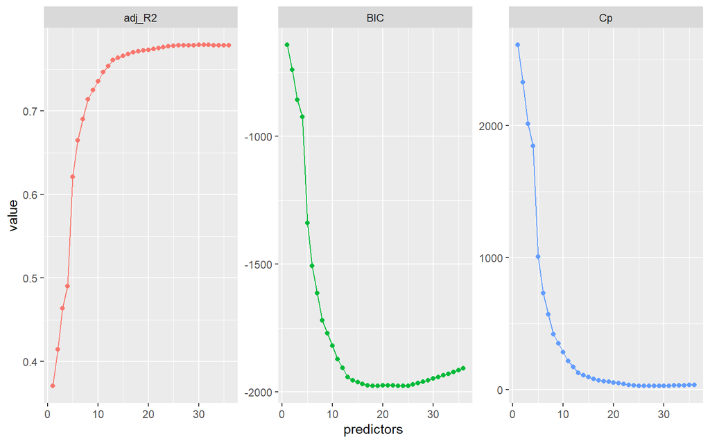

```r
results <- summary(best_subset_WG5)

# Extrahieren und plotten der Ergebnisse
tibble(predictors = 1:36,
       adj_R2 = results$adjr2,
       Cp = results$cp,
       BIC = results$bic) %>%
  gather(statistic, value, -predictors) %>%
  ggplot(aes(predictors, value, color = statistic)) +
  geom_line(show.legend = F) +
  geom_point(show.legend = F) +
  facet_wrap(~ statistic, scales = "free")
```

```r
which.max(results$adjr2)
```

```
## [1] 31
```

```r
which.min(results$bic)
```

```
## [1] 23
```

```r
which.min(results$cp)
```

```
## [1] 27
```

Es ist erkennbar, dass die Ergebnisse leicht unterschiedliche Modelle identifizieren, die als die besten angesehen werden. Die ajustierte $R^2$-Statistik legt nahe, dass ein 31-Variablen-Modell bevorzugt wird, die $BIC$-Statistik schlägt ein 23-Variablenmodell vor und der $C_p$ ein 27-Variablen-Modell vor.

Die Variablen und Koeffizienten, die diese Modelle enthalten, können mittels der `coef`-Funktion verglichen werden:

Der gleiche Prozess kann durch schrittweise Vorwärts- und Rückwärtsauswahl durchgeführt werden, um noch mehr Optionen für optimale Modelle zu erhalten:

```r
forward <- regsubsets(Umsatz ~ ., df_lm_train_WG5, nvmax = 36, method = "forward")
backward <- regsubsets(Umsatz ~ ., df_lm_train_WG5, nvmax = 36, method = "backward")

# Welches Modell minimiert den Cp?
which.min(summary(forward)$cp)
```

```
## [1] 28
```

```r
which.min(summary(backward)$cp)
```

```
## [1] 26
```

Wenn man das optimale $C_p$ für vorwärts und rückwärts schrittweise bewertet, ist erkennbar, dass gemäß der Vorwärts-Methode ein 28-Variablen-Modell die $C_p$-Statistik minimiert. Die Rückwärtsmethode schlägt ein 26-Variablen-Modell vor.

Wenn wir diese Modelle bewerten, ergibt sich bzgl. der Zusammensetzung der Prädikatoren-Stes folgendes Bild:.

```r
# 23-Variablen-Modell
coef(best_subset_WG2, 23)
```

```
##            (Intercept)            KielerWoche             Bewoelkung
##             301.250888              94.057770              -1.797666
##             Temperatur     Wochentag_cFreitag     Wochentag_cSamstag
##               2.734308              16.662111             116.628698
##     Wochentag_cSonntag         Monat_cFebruar          Monat_cJanuar
##             174.275923             -19.850592             -31.638704
##            Monat_cJuni            Monat_cMärz         Monat_cOktober
##              20.493295             -30.924607              76.758787
##         SommerferienSH        SommerferienNRW        SommerferienNDS
##              51.694084              89.140944              30.641686
##         SommerferienHE               Feiertag                 Ostern
##              54.560830             102.718009             -78.007547
##             Ostern_ext ChristiHimmelfahrt_ext          Pfingsten_ext
##             225.362002              91.871933              73.486780
##          Silvester_ext       JahreszeitHerbst       JahreszeitSommer
##             157.120502             -40.761042              18.511756
```

```r
# 26-Variablen-Modell
coef(best_subset_WG2, 26)
```

```
##            (Intercept)            KielerWoche             Bewoelkung
##            298.4058891            106.4001612             -1.9601782
##             Temperatur    Windgeschwindigkeit     Wochentag_cFreitag
##              2.2603774              0.6562782             16.6265420
##     Wochentag_cSamstag     Wochentag_cSonntag          Monat_cAugust
##            116.2050194            173.9271810             30.7823571
##         Monat_cFebruar          Monat_cJanuar            Monat_cJuli
##            -21.0649132            -33.7019731             30.7734204
##            Monat_cJuni            Monat_cMärz         Monat_cOktober
##             27.8575210            -31.1960221             82.4069891
##       Monat_cSeptember         SommerferienSH        SommerferienNRW
##             23.8591045             50.0767350             85.7216200
##        SommerferienNDS         SommerferienHE               Feiertag
##             31.0085289             51.9384915            102.2313522
##                 Ostern             Ostern_ext ChristiHimmelfahrt_ext
##            -75.4954444            223.6163126             94.3633522
##          Pfingsten_ext          Silvester_ext       JahreszeitHerbst
##             74.2712983            156.5130094            -43.1068555
```

```r
# 27-Variablen-Modell
coef(best_subset_WG2, 27)
```

```
##            (Intercept)            KielerWoche             Bewoelkung
##            300.4426300            106.4081526             -1.9944071
##             Temperatur    Windgeschwindigkeit     Wochentag_cFreitag
##              2.2458640              0.6731218             14.7321877
##    Wochentag_cMittwoch     Wochentag_cSamstag     Wochentag_cSonntag
##             -7.3828287            114.3262895            172.0672918
##          Monat_cAugust         Monat_cFebruar          Monat_cJanuar
##             31.1385438            -21.1880439            -33.8672705
##            Monat_cJuli            Monat_cJuni            Monat_cMärz
##             31.2779417             27.9457291            -31.2614621
##         Monat_cOktober       Monat_cSeptember         SommerferienSH
##             82.4987784             23.9082216             50.1380316
##        SommerferienNRW        SommerferienNDS         SommerferienHE
##             85.2740232             30.9085069             51.9845646
##               Feiertag                 Ostern             Ostern_ext
##            101.1324749            -74.4678250            222.6716868
## ChristiHimmelfahrt_ext          Pfingsten_ext          Silvester_ext
##             95.2641385             73.8723795            157.9220733
##       JahreszeitHerbst
##            -43.1588521
```

```r
# 28-Variablen-Modell
coef(best_subset_WG2, 28)
```

```
##            (Intercept)            KielerWoche             Bewoelkung
##            299.8776862            106.2921307             -1.9639509
##             Temperatur    Windgeschwindigkeit     Wochentag_cFreitag
##              2.2656223              0.6794816             14.5577923
##    Wochentag_cMittwoch     Wochentag_cSamstag     Wochentag_cSonntag
##             -7.2197744            114.2026602            172.6708574
##          Monat_cAugust         Monat_cFebruar          Monat_cJanuar
##             31.0020793            -21.0191703            -33.6638528
##            Monat_cJuli            Monat_cJuni            Monat_cMärz
##             31.1509408             27.9426583            -31.0538129
##         Monat_cOktober       Monat_cSeptember         SommerferienSH
##             81.8368548             23.8411205             50.1837918
##        SommerferienNRW        SommerferienNDS         SommerferienHE
##             85.2628970             30.8781814             52.0329144
##     ChristiHimmelfahrt              Pfingsten                    TDE
##            113.6871502            107.6889886            117.9701401
##             Ostern_ext ChristiHimmelfahrt_ext          Pfingsten_ext
##            236.8914773             92.7344715             70.5223734
##          Silvester_ext       JahreszeitHerbst
##            208.6224408            -43.0396032
```

```r
# 31-Variablen-Modell
coef(best_subset_WG2, 31)
```

```
##            (Intercept)            KielerWoche             Bewoelkung
##            293.0113864            117.9568840             -1.9211801
##             Temperatur    Windgeschwindigkeit     Wochentag_cFreitag
##              2.5069296              0.6727934             14.5933059
##    Wochentag_cMittwoch     Wochentag_cSamstag     Wochentag_cSonntag
##             -7.1085068            114.0389427            172.4127971
##          Monat_cAugust        Monat_cDezember          Monat_cJanuar
##             51.7213242             33.5731131            -13.5143658
##            Monat_cJuli            Monat_cJuni            Monat_cMärz
##             50.1873647             32.5206859            -17.5128608
##        Monat_cNovember         Monat_cOktober       Monat_cSeptember
##             37.3224676            114.7856739             48.0454212
##         SommerferienSH        SommerferienNRW        SommerferienNDS
##             49.5018200             86.7519574             34.0314310
##         SommerferienHE     ChristiHimmelfahrt              Pfingsten
##             49.5111317            114.4060608            107.8570538
##                    TDE             Ostern_ext ChristiHimmelfahrt_ext
##            117.2474784            238.7638569             95.3318619
##          Pfingsten_ext          Silvester_ext       JahreszeitHerbst
##             71.1288325            194.5744842            -72.2772230
##       JahreszeitSommer       JahreszeitWinter
##            -18.8157120            -13.9950373
```

### Direkte Schätzung des Testfehlers

Nun wird der Fehler der Testdaten für das beste Modell jeder Modellgröße berechnet. Zuerst wird eine Modellmatrix aus den Testdaten erstellt. Die Funktion `model.matrix` wird in vielen Regressionspaketen zum Erstellen einer X-Matrix aus Daten verwendet.

```r
test_m <- model.matrix(Umsatz ~ ., data = df_lm_test_WG5)
```

```r
# Erstellen eines leeren Vektors, um diesen nachfolgend mit den Fehlerwerten zu füllen
validation_errors <- vector("double", length = 36)

for(i in 1:36) {
  coef_x <- coef(best_subset_WG5, id = i)                     # extract coefficients for model size i
  pred_x <- test_m[ , names(coef_x)] %*% coef_x           # predict salary using matrix algebra
  validation_errors[i] <- mean((df_lm_test_WG5$Umsatz - pred_x)^2)  # compute test error btwn actual & predicted salary
}

as.matrix(validation_errors)
```

```
##           [,1]
##  [1,] 5961.308
##  [2,] 5625.944
##  [3,] 4793.030
##  [4,] 4611.951
##  [5,] 3674.561
##  [6,] 2912.423
##  [7,] 2756.433
##  [8,] 2583.962
##  [9,] 2643.741
## [10,] 2569.861
## [11,] 2629.672
## [12,] 2617.751
## [13,] 2626.376
## [14,] 2598.037
```

[output cut: 22 more lines]

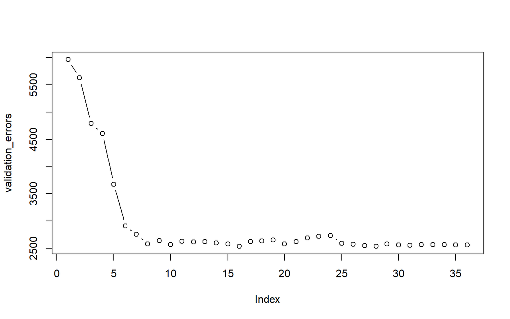

```r
# Plotten der validation errors
plot(validation_errors, type = "b")
```

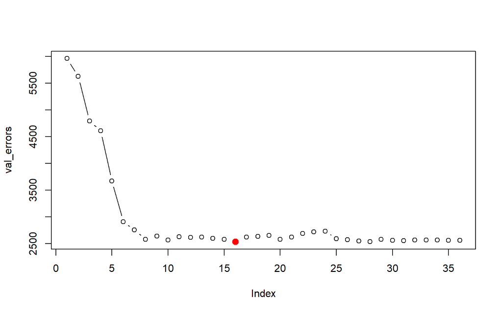

```r
#############################
# Alternative: http://www.science.smith.edu/~jcrouser/SDS293/labs/lab9-r.html
val_errors = rep(NA,36)

# Iterationen über jede Größe i
for(i in 1:36){

    # Extrahieren des Vektors der Prädiktoren im Best-Fit-Modell für i-Prädiktoren
    coefi = coef(best_subset_WG5, id = i)

    # Vorhersagen unter Verwendung der Matrixmultiplikation der Testmatrix und des Koeffizientenvektors erstellen
    pred = test_m[,names(coefi)]%*%coefi

    # Berechnung des MSE
    val_errors[i] = mean((df_lm_test_WG5$Umsatz-pred)^2)
}

# Auffinden des Modells mit dem kleinsten Fehler
min = which.min(val_errors)

# Plotten des Fehlers für jede Modellgröße
plot(val_errors, type = 'b')
points(min, val_errors[min][1], col = "red", cex = 2, pch = 20)
```

Es ist erkennbar, dass das 16-Variablen-Modell, das durch den besten Teilmengenansatz erzeugt wird, den niedrigsten Test-MSE erzeugt. Auch ein 27/28- sowie 10-Variablen-Modell scheinen vergleichweichsweise gut zu performen.

Wir können jetzt die beste Teilmengenauswahl für den gesamten Datensatz durchführen, um zum einen das 16-Variablen-Modell zu erhalten. Dieses Modell wird mit dem 10-und dem 28-Variablen-Modell verglichen.

**Teilmengenauswahl für das 16-Variablen-Modell**

```r
final_best_WG5_16 <- regsubsets(Umsatz ~ ., data = df_lm_train_WG5, nvmax = 36)
coef(final_best_WG5_16, 16)
```

```
##        (Intercept) Wochentag_cFreitag Wochentag_cSamstag
##          249.72536           16.66969           51.68771
## Wochentag_cSonntag      Monat_cAugust    Monat_cDezember
##           48.26968           34.83759          -46.80853
##     Monat_cFebruar    Monat_cNovember           Feiertag
##           28.33683          -33.11208         1300.37500
##             Ostern ChristiHimmelfahrt          Pfingsten
##        -1416.90490        -1216.92786        -1227.69895
##                TDE         Ostern_ext      Silvester_ext
##        -1236.63221          142.41595          207.73776
##   JahreszeitSommer   JahreszeitWinter
##           27.08401          -14.27894
```

Die 16 Variablen sind die folgenden:

- Wochentag_cFreitag
- Wochentag_cSamstag
- Wochentag_cSonntag
- Monat_cAugust
- Monat_cDezember
- Monat_cFebruar
- Monat_cNovember
- Feiertag
- Ostern
- ChristiHimmelfahrt
- Pfingsten
- TDE
- Ostern_ext
- Silvester_ext
- JahreszeitSommer
- JahreszeitWinter

Die Variablen Wochentag_c, Monat_c und Jahreszeit müssen nun noch dummyfiziert werden (bei Einbeziehung aller Variablen erfolgt die Dummyfizierung automatisch im Rahmen der Regressionsanalyse): Für jeden Wochentag wird eine Variable mit Ausprägung 0/1 gebildet und danach die alte Variable Wochentag_c entfernt. Analog wird bei den beiden anderen Variablen vorgegangen.

```r
# Dummyfizierung der Variablen im Trainigsdatensatz:
df_lm_train_WG5_16 <- df_lm_train_WG5 %>%
  mutate(Montag=as.integer(df_lm_train_WG5$Wochentag_c=="Montag")) %>%
  mutate(Dienstag=as.integer(df_lm_train_WG5$Wochentag_c=="Dienstag")) %>%
  mutate(Mittwoch=as.integer(df_lm_train_WG5$Wochentag_c=="Mittwoch")) %>%
  mutate(Donnerstag=as.integer(df_lm_train_WG5$Wochentag_c=="Donnerstag")) %>%
  mutate(Freitag=as.integer(df_lm_train_WG5$Wochentag_c=="Freitag")) %>%
  mutate(Samstag=as.integer(df_lm_train_WG5$Wochentag_c=="Samstag")) %>%
  mutate(Sonntag=as.integer(df_lm_train_WG5$Wochentag_c=="Sonntag")) %>%
  mutate(Januar=as.integer(df_lm_train_WG5$Monat_c=="Januar")) %>%
  mutate(Februar=as.integer(df_lm_train_WG5$Monat_c=="Februar")) %>%
  mutate(Maerz=as.integer(df_lm_train_WG5$Monat_c=="März")) %>%
  mutate(April=as.integer(df_lm_train_WG5$Monat_c=="April")) %>%
  mutate(Mai=as.integer(df_lm_train_WG5$Monat_c=="Mai")) %>%
  mutate(Juni=as.integer(df_lm_train_WG5$Monat_c=="Juni")) %>%
  mutate(Juli=as.integer(df_lm_train_WG5$Monat_c=="Juli")) %>%
  mutate(August=as.integer(df_lm_train_WG5$Monat_c=="August")) %>%
  mutate(September=as.integer(df_lm_train_WG5$Monat_c=="September")) %>%
  mutate(Oktober=as.integer(df_lm_train_WG5$Monat_c=="Oktober")) %>%
  mutate(November=as.integer(df_lm_train_WG5$Monat_c=="November")) %>%
  mutate(Dezember=as.integer(df_lm_train_WG5$Monat_c=="Dezember")) %>%
  mutate(Fruehling=as.integer(df_lm_train_WG5$Jahreszeit=="Fruehling")) %>%
  mutate(Sommer=as.integer(df_lm_train_WG5$Jahreszeit=="Sommer")) %>%
  mutate(Herbst=as.integer(df_lm_train_WG5$Jahreszeit=="Herbst")) %>%
  mutate(Winter=as.integer(df_lm_train_WG5$Jahreszeit=="Winter")) %>%
  dplyr::select(-Wochentag_c, -Monat_c, -Jahreszeit)

df_lm_test_WG5_16 <- df_lm_test_WG5 %>%
  mutate(Montag=as.integer(df_lm_test_WG5$Wochentag_c=="Montag")) %>%
  mutate(Dienstag=as.integer(df_lm_test_WG5$Wochentag_c=="Dienstag")) %>%
  mutate(Mittwoch=as.integer(df_lm_test_WG5$Wochentag_c=="Mittwoch")) %>%
  mutate(Donnerstag=as.integer(df_lm_test_WG5$Wochentag_c=="Donnerstag")) %>%
  mutate(Freitag=as.integer(df_lm_test_WG5$Wochentag_c=="Freitag")) %>%
  mutate(Samstag=as.integer(df_lm_test_WG5$Wochentag_c=="Samstag")) %>%
  mutate(Sonntag=as.integer(df_lm_test_WG5$Wochentag_c=="Sonntag")) %>%
  mutate(Januar=as.integer(df_lm_test_WG5$Monat_c=="Januar")) %>%
  mutate(Februar=as.integer(df_lm_test_WG5$Monat_c=="Februar")) %>%
  mutate(Maerz=as.integer(df_lm_test_WG5$Monat_c=="März")) %>%
  mutate(April=as.integer(df_lm_test_WG5$Monat_c=="April")) %>%
  mutate(Mai=as.integer(df_lm_test_WG5$Monat_c=="Mai")) %>%
  mutate(Juni=as.integer(df_lm_test_WG5$Monat_c=="Juni")) %>%
  mutate(Juli=as.integer(df_lm_test_WG5$Monat_c=="Juli")) %>%
  mutate(August=as.integer(df_lm_test_WG5$Monat_c=="August")) %>%
  mutate(September=as.integer(df_lm_test_WG5$Monat_c=="September")) %>%
  mutate(Oktober=as.integer(df_lm_test_WG5$Monat_c=="Oktober")) %>%
  mutate(November=as.integer(df_lm_test_WG5$Monat_c=="November")) %>%
  mutate(Dezember=as.integer(df_lm_test_WG5$Monat_c=="Dezember")) %>%
  mutate(Fruehling=as.integer(df_lm_test_WG5$Jahreszeit=="Fruehling")) %>%
  mutate(Sommer=as.integer(df_lm_test_WG5$Jahreszeit=="Sommer")) %>%
  mutate(Herbst=as.integer(df_lm_test_WG5$Jahreszeit=="Herbst")) %>%
  mutate(Winter=as.integer(df_lm_test_WG5$Jahreszeit=="Winter")) %>%
  dplyr::select(-Wochentag_c, -Monat_c, -Jahreszeit)
```

Für das 16-Variablenmodell wird nun ein Regressionsmodell erstellt:

```r
lm_WG5_16_train <- lm(Umsatz ~ Freitag + Samstag + Sonntag + August +  Dezember + Februar + November + Feiertag + Ostern + ChristiHimmelfahrt + Pfingsten + TDE + Ostern_ext + Silvester_ext + Sommer + Winter, data = df_lm_train_WG5_16)

glance(lm_WG5_16_train)
```

```
## # A tibble: 1 x 11
##   r.squared adj.r.squared sigma statistic p.value    df logLik    AIC
##       <dbl>         <dbl> <dbl>     <dbl>   <dbl> <int>  <dbl>  <dbl>
## 1     0.771         0.768  47.2      295.       0    17 -7478. 14993.
## # ... with 3 more variables: BIC <dbl>, deviance <dbl>, df.residual <int>
```

Dann wird (die Modellgüte) anhand der *Test*-Stichprobe getestet:

```r
lm_WG5_16_predict <- predict(lm_WG5_16_train, newdata = df_lm_test_WG5_16)
```

Als Ergebnis wird ein Vektor erzeugt, der für jede Beobachtung des Test-Samples den geschätzten (vorhergesagten) Umsatzwert speichert. Die Gütewerte lassen sich mit `caret::postResample` ausgeben:

```r
caret::postResample(pred = lm_WG5_16_predict, obs = df_lm_test_WG5_16$Umsatz)
```

```
##       RMSE   Rsquared        MAE
## 50.3755948  0.7299486 37.6690892
```

Diese Vorhersage-Ergebnisse werden den Test-Daten hinzugefügt, sodann die Gütekennzahlen berechnet, die wiederum der gemeinsamen Übersichtstabelle für die Gütekennzahlen `lm_vgl_kennz` hinzugefügt werden:

```r
# Hinzufügen der Ergebnisse
df_lm_test_WG5_16 <- df_lm_test_WG5_16 %>%
  mutate(predicted = lm_WG5_16_predict)

# ergänze Prognose_zuhoch (TRUE / FALSE), Abweichung (Schätzer - Umsatz), absolute Abweichung (Abweichung_abs), relative Abweichung (Abweichung_rel), quadratische Abweichung (Abweichung_quad)
df_lm_test_WG5_16 <-df_lm_test_WG5_16 %>%
  mutate(Prognose_zuhoch = (predicted >= Umsatz)) %>%
  mutate(Abweichung = predicted - Umsatz) %>%
  mutate(Abweichung_abs = abs(predicted - Umsatz)) %>%
  mutate(Abweichung_rel = (predicted - Umsatz) / Umsatz) %>%
  mutate(Abweichung_quad = Abweichung^2)

# Ergänze die benötigten Hilfsgrößen
df_lm_test_WG5_16 <- df_lm_test_WG5_16 %>%
  mutate(Abweichung_rel_abs = abs(Abweichung_rel), Abweichung_rel_abs_mult_umsatz = Abweichung_rel_abs * Umsatz)

# Prognosegüte: mittlere Abweichung, mittlere absolute / relative Abweichung, mittlere quadratische Abweichung
temp <- df_lm_test_WG5_16 %>%
  group_by() %>%
  summarise(Anzahl=n(), Umsatz_ges = round(sum(Umsatz)), Umsatz_mittel = round(sum(Umsatz)/n()), MAE = round(mean(Abweichung_abs)), MPE = round(mean(Abweichung_rel)*100), MAPE = round(mean(Abweichung_rel_abs)*100), WAPE = round(sum(Abweichung_rel_abs_mult_umsatz)/sum(Umsatz)*100), MSE = round(mean(Abweichung_quad)), RMSE = round(sqrt(mean(Abweichung_quad))))

# füge das Modell hinzu
temp <- temp %>% mutate(Modell = "best16_WG5")

# füge die Kennzahlen nun an die Vergleichstabelle
lm_vgl_kennz <- rbind(lm_vgl_kennz, temp)
lm_vgl_kennz
```

```
## # A tibble: 6 x 10
##   Anzahl Umsatz_ges Umsatz_mittel   MAE   MPE  MAPE  WAPE   MSE  RMSE
##    <int>      <dbl>         <dbl> <dbl> <dbl> <dbl> <dbl> <dbl> <dbl>
## 1    346      45738           132    23    -4    18    18   965    31
## 2    346      45738           132    23    -4    18    18   949    31
## 3    346     130413           377    45     9    13    12  3161    56
## 4    346     130413           377    45     9    13    12  3189    56
## 5    346     130413           377    45     9    13    12  3197    57
## 6    346      93912           271    38     4    15    14  2538    50
## # ... with 1 more variable: Modell <chr>
```

**Teilmengenauswahl für das 10-Variablen-Modell**

```r
final_best_WG5_10 <- regsubsets(Umsatz ~ ., data = df_lm_train_WG5, nvmax = 36)
coef(final_best_WG5_10, 10)
```

```
##        (Intercept) Wochentag_cSamstag Wochentag_cSonntag
##          248.52590           50.84156           44.15509
##    Monat_cDezember           Feiertag             Ostern
##          -46.09735         1297.23623        -1268.09343
## ChristiHimmelfahrt          Pfingsten                TDE
##        -1212.58963        -1221.30343        -1227.91502
##      Silvester_ext   JahreszeitSommer
##          198.32605           42.79698
```

Die 10 Variablen sind die folgenden:

- Wochentag_cSamstag
- Wochentag_cSonntag
- Monat_cDezember
- Feiertag
- Ostern
- ChristiHimmelfahrt
- Pfingsten
- TDE
- Silvester_ext
- JahreszeitSommer

Die Variablen Wochentag_c, Monat_c und Jahreszeit müssen nun noch dummyfiziert werden (bei Einbeziehung aller Variablen erfolgt die Dummyfizierung automatisch im Rahmen der Regressionsanalyse): Für jeden Wochentag wird eine Variable mit Ausprägung 0/1 gebildet und danach die alte Variable Wochentag_c entfernt. Analog wird bei den beiden anderen Variablen vorgegangen.

```r
# Dummyfizierung der Variablen im Trainigsdatensatz:
df_lm_train_WG5_10 <- df_lm_train_WG5 %>%
  mutate(Montag=as.integer(df_lm_train_WG5$Wochentag_c=="Montag")) %>%
  mutate(Dienstag=as.integer(df_lm_train_WG5$Wochentag_c=="Dienstag")) %>%
  mutate(Mittwoch=as.integer(df_lm_train_WG5$Wochentag_c=="Mittwoch")) %>%
  mutate(Donnerstag=as.integer(df_lm_train_WG5$Wochentag_c=="Donnerstag")) %>%
  mutate(Freitag=as.integer(df_lm_train_WG5$Wochentag_c=="Freitag")) %>%
  mutate(Samstag=as.integer(df_lm_train_WG5$Wochentag_c=="Samstag")) %>%
  mutate(Sonntag=as.integer(df_lm_train_WG5$Wochentag_c=="Sonntag")) %>%
  mutate(Januar=as.integer(df_lm_train_WG5$Monat_c=="Januar")) %>%
  mutate(Februar=as.integer(df_lm_train_WG5$Monat_c=="Februar")) %>%
  mutate(Maerz=as.integer(df_lm_train_WG5$Monat_c=="März")) %>%
  mutate(April=as.integer(df_lm_train_WG5$Monat_c=="April")) %>%
  mutate(Mai=as.integer(df_lm_train_WG5$Monat_c=="Mai")) %>%
  mutate(Juni=as.integer(df_lm_train_WG5$Monat_c=="Juni")) %>%
  mutate(Juli=as.integer(df_lm_train_WG5$Monat_c=="Juli")) %>%
  mutate(August=as.integer(df_lm_train_WG5$Monat_c=="August")) %>%
  mutate(September=as.integer(df_lm_train_WG5$Monat_c=="September")) %>%
  mutate(Oktober=as.integer(df_lm_train_WG5$Monat_c=="Oktober")) %>%
  mutate(November=as.integer(df_lm_train_WG5$Monat_c=="November")) %>%
  mutate(Dezember=as.integer(df_lm_train_WG5$Monat_c=="Dezember")) %>%
  mutate(Fruehling=as.integer(df_lm_train_WG5$Jahreszeit=="Fruehling")) %>%
  mutate(Sommer=as.integer(df_lm_train_WG5$Jahreszeit=="Sommer")) %>%
  mutate(Herbst=as.integer(df_lm_train_WG5$Jahreszeit=="Herbst")) %>%
  mutate(Winter=as.integer(df_lm_train_WG5$Jahreszeit=="Winter")) %>%
  dplyr::select(-Wochentag_c, -Monat_c, -Jahreszeit)

df_lm_test_WG5_10 <- df_lm_test_WG5 %>%
  mutate(Montag=as.integer(df_lm_test_WG5$Wochentag_c=="Montag")) %>%
  mutate(Dienstag=as.integer(df_lm_test_WG5$Wochentag_c=="Dienstag")) %>%
  mutate(Mittwoch=as.integer(df_lm_test_WG5$Wochentag_c=="Mittwoch")) %>%
  mutate(Donnerstag=as.integer(df_lm_test_WG5$Wochentag_c=="Donnerstag")) %>%
  mutate(Freitag=as.integer(df_lm_test_WG5$Wochentag_c=="Freitag")) %>%
  mutate(Samstag=as.integer(df_lm_test_WG5$Wochentag_c=="Samstag")) %>%
  mutate(Sonntag=as.integer(df_lm_test_WG5$Wochentag_c=="Sonntag")) %>%
  mutate(Januar=as.integer(df_lm_test_WG5$Monat_c=="Januar")) %>%
  mutate(Februar=as.integer(df_lm_test_WG5$Monat_c=="Februar")) %>%
  mutate(Maerz=as.integer(df_lm_test_WG5$Monat_c=="März")) %>%
  mutate(April=as.integer(df_lm_test_WG5$Monat_c=="April")) %>%
  mutate(Mai=as.integer(df_lm_test_WG5$Monat_c=="Mai")) %>%
  mutate(Juni=as.integer(df_lm_test_WG5$Monat_c=="Juni")) %>%
  mutate(Juli=as.integer(df_lm_test_WG5$Monat_c=="Juli")) %>%
  mutate(August=as.integer(df_lm_test_WG5$Monat_c=="August")) %>%
  mutate(September=as.integer(df_lm_test_WG5$Monat_c=="September")) %>%
  mutate(Oktober=as.integer(df_lm_test_WG5$Monat_c=="Oktober")) %>%
  mutate(November=as.integer(df_lm_test_WG5$Monat_c=="November")) %>%
  mutate(Dezember=as.integer(df_lm_test_WG5$Monat_c=="Dezember")) %>%
  mutate(Fruehling=as.integer(df_lm_test_WG5$Jahreszeit=="Fruehling")) %>%
  mutate(Sommer=as.integer(df_lm_test_WG5$Jahreszeit=="Sommer")) %>%
  mutate(Herbst=as.integer(df_lm_test_WG5$Jahreszeit=="Herbst")) %>%
  mutate(Winter=as.integer(df_lm_test_WG5$Jahreszeit=="Winter")) %>%
  dplyr::select(-Wochentag_c, -Monat_c, -Jahreszeit)
```

Für das 10-Variablenmodell wird nun ein Regressionsmodell erstellt:

- Wochentag_cSamstag
- Wochentag_cSonntag
- Monat_cDezember
- Feiertag
- Ostern
- ChristiHimmelfahrt
- Pfingsten
- TDE
- Silvester_ext
- JahreszeitSommer

```r
lm_WG5_10_train <- lm(Umsatz ~ Samstag + Sonntag + Dezember + Feiertag + Ostern + ChristiHimmelfahrt + Pfingsten + TDE + Silvester_ext + Sommer, data = df_lm_train_WG5_16)

glance(lm_WG5_16_train)
```

```
## # A tibble: 1 x 11
##   r.squared adj.r.squared sigma statistic p.value    df logLik    AIC
##       <dbl>         <dbl> <dbl>     <dbl>   <dbl> <int>  <dbl>  <dbl>
## 1     0.771         0.768  47.2      295.       0    17 -7478. 14993.
## # ... with 3 more variables: BIC <dbl>, deviance <dbl>, df.residual <int>
```

Dann wird (die Modellgüte) anhand der *Test*-Stichprobe getestet:

```r
lm_WG5_10_predict <- predict(lm_WG5_10_train, newdata = df_lm_test_WG5_10)
```

Als Ergebnis wird ein Vektor erzeugt, der für jede Beobachtung des Test-Samples den geschätzten (vorhergesagten) Umsatzwert speichert. Die Gütewerte lassen sich mit `caret::postResample` ausgeben:

```r
caret::postResample(pred = lm_WG5_10_predict, obs = df_lm_test_WG5_10$Umsatz)
```

```
##       RMSE   Rsquared        MAE
## 50.6938004  0.7254496 38.9986394
```

Diese Vorhersage-Ergebnisse werden den Test-Daten hinzugefügt, sodann die Gütekennzahlen berechnet, die wiederum der gemeinsamen Übersichtstabelle für die Gütekennzahlen `lm_vgl_kennz` hinzugefügt werden:

```r
# Hinzufügen der Ergebnisse
df_lm_test_WG5_10 <- df_lm_test_WG5_10 %>%
  mutate(predicted = lm_WG5_10_predict)

# ergänze Prognose_zuhoch (TRUE / FALSE), Abweichung (Schätzer - Umsatz), absolute Abweichung (Abweichung_abs), relative Abweichung (Abweichung_rel), quadratische Abweichung (Abweichung_quad)
df_lm_test_WG5_10 <-df_lm_test_WG5_10 %>%
  mutate(Prognose_zuhoch = (predicted >= Umsatz)) %>%
  mutate(Abweichung = predicted - Umsatz) %>%
  mutate(Abweichung_abs = abs(predicted - Umsatz)) %>%
  mutate(Abweichung_rel = (predicted - Umsatz) / Umsatz) %>%
  mutate(Abweichung_quad = Abweichung^2)

# Ergänze die benötigten Hilfsgrößen
df_lm_test_WG5_10 <- df_lm_test_WG5_10 %>%
  mutate(Abweichung_rel_abs = abs(Abweichung_rel), Abweichung_rel_abs_mult_umsatz = Abweichung_rel_abs * Umsatz)

# Prognosegüte: mittlere Abweichung, mittlere absolute / relative Abweichung, mittlere quadratische Abweichung
temp <- df_lm_test_WG5_10 %>%
  group_by() %>%
  summarise(Anzahl=n(), Umsatz_ges = round(sum(Umsatz)), Umsatz_mittel = round(sum(Umsatz)/n()), MAE = round(mean(Abweichung_abs)), MPE = round(mean(Abweichung_rel)*100), MAPE = round(mean(Abweichung_rel_abs)*100), WAPE = round(sum(Abweichung_rel_abs_mult_umsatz)/sum(Umsatz)*100), MSE = round(mean(Abweichung_quad)), RMSE = round(sqrt(mean(Abweichung_quad))))

# füge das Modell hinzu
temp <- temp %>% mutate(Modell = "best10_WG5")

# füge die Kennzahlen nun an die Vergleichstabelle
lm_vgl_kennz <- rbind(lm_vgl_kennz, temp)
lm_vgl_kennz
```

```
## # A tibble: 7 x 10
##   Anzahl Umsatz_ges Umsatz_mittel   MAE   MPE  MAPE  WAPE   MSE  RMSE
##    <int>      <dbl>         <dbl> <dbl> <dbl> <dbl> <dbl> <dbl> <dbl>
## 1    346      45738           132    23    -4    18    18   965    31
## 2    346      45738           132    23    -4    18    18   949    31
## 3    346     130413           377    45     9    13    12  3161    56
## 4    346     130413           377    45     9    13    12  3189    56
## 5    346     130413           377    45     9    13    12  3197    57
## 6    346      93912           271    38     4    15    14  2538    50
## 7    346      93912           271    39     4    15    14  2570    51
## # ... with 1 more variable: Modell <chr>
```

**Teilmengenauswahl für das 28-Variablen-Modell**

```r
final_best_WG5_28 <- regsubsets(Umsatz ~ ., data = df_lm_train_WG5, nvmax = 36)
coef(final_best_WG5_28, 28)
```

```
##        (Intercept)        KielerWoche         Bewoelkung
##         270.582678          17.588695          -1.679758
##         Temperatur Wochentag_cFreitag  Wochentag_cMontag
##          -1.855428          14.444043         -10.009566
## Wochentag_cSamstag Wochentag_cSonntag      Monat_cAugust
##          49.272882          46.327127          33.755567
##    Monat_cDezember     Monat_cFebruar        Monat_cJuli
##         -22.226035          31.576312          14.523265
##        Monat_cJuni         Monat_cMai     Monat_cOktober
##          30.706013          22.246078          48.138558
##   Monat_cSeptember     SommerferienSH    SommerferienNRW
##          36.228830          21.973377           8.385879
##     SommerferienHE           Feiertag             Ostern
##          18.801835        1303.646468       -1414.870428
## ChristiHimmelfahrt          Pfingsten                TDE
##       -1230.986189       -1236.107382       -1240.001303
##         Ostern_ext      Silvester_ext   JahreszeitHerbst
##         147.016249         185.737014         -28.827390
##   JahreszeitSommer   JahreszeitWinter
##          12.932174         -18.124977
```

Die 28 Variablen sind die folgenden:

- KielerWoche
- Bewoelkung
- Temperatur
- Wochentag_cFreitag
- Wochentag_cMontag
- Wochentag_cSamstag
- Wochentag_cSonntag
- Monat_cAugust
- Monat_cDezember
- Monat_cFebruar
- Monat_cJuli
- Monat_cJuni
- Monat_cMai
- Monat_cOktober
- Monat_cSeptember
- SommerferienSH
- SommerferienNRW
- SommerferienHE
- Feiertag
- Ostern
- ChristiHimmelfahrt
- Pfingsten
- TDE
- Ostern_ext
- Silvester_ext
- JahreszeitHerbst
- JahreszeitSommer
- JahreszeitWinter

Die Variablen Wochentag_c, Monat_c und Jahreszeit müssen nun noch dummyfiziert werden (bei Einbeziehung aller Variablen erfolgt die Dummyfizierung automatisch im Rahmen der Regressionsanalyse): Für jeden Wochentag wird eine Variable mit Ausprägung 0/1 gebildet und danach die alte Variable Wochentag_c entfernt. Analog wird bei den beiden anderen Variablen vorgegangen.

```r
# Dummyfizierung der Variablen im Trainigsdatensatz:
df_lm_train_WG5_28 <- df_lm_train_WG5 %>%
  mutate(Montag=as.integer(df_lm_train_WG5$Wochentag_c=="Montag")) %>%
  mutate(Dienstag=as.integer(df_lm_train_WG5$Wochentag_c=="Dienstag")) %>%
  mutate(Mittwoch=as.integer(df_lm_train_WG5$Wochentag_c=="Mittwoch")) %>%
  mutate(Donnerstag=as.integer(df_lm_train_WG5$Wochentag_c=="Donnerstag")) %>%
  mutate(Freitag=as.integer(df_lm_train_WG5$Wochentag_c=="Freitag")) %>%
  mutate(Samstag=as.integer(df_lm_train_WG5$Wochentag_c=="Samstag")) %>%
  mutate(Sonntag=as.integer(df_lm_train_WG5$Wochentag_c=="Sonntag")) %>%
  mutate(Januar=as.integer(df_lm_train_WG5$Monat_c=="Januar")) %>%
  mutate(Februar=as.integer(df_lm_train_WG5$Monat_c=="Februar")) %>%
  mutate(Maerz=as.integer(df_lm_train_WG5$Monat_c=="März")) %>%
  mutate(April=as.integer(df_lm_train_WG5$Monat_c=="April")) %>%
  mutate(Mai=as.integer(df_lm_train_WG5$Monat_c=="Mai")) %>%
  mutate(Juni=as.integer(df_lm_train_WG5$Monat_c=="Juni")) %>%
  mutate(Juli=as.integer(df_lm_train_WG5$Monat_c=="Juli")) %>%
  mutate(August=as.integer(df_lm_train_WG5$Monat_c=="August")) %>%
  mutate(September=as.integer(df_lm_train_WG5$Monat_c=="September")) %>%
  mutate(Oktober=as.integer(df_lm_train_WG5$Monat_c=="Oktober")) %>%
  mutate(November=as.integer(df_lm_train_WG5$Monat_c=="November")) %>%
  mutate(Dezember=as.integer(df_lm_train_WG5$Monat_c=="Dezember")) %>%
  mutate(Fruehling=as.integer(df_lm_train_WG5$Jahreszeit=="Fruehling")) %>%
  mutate(Sommer=as.integer(df_lm_train_WG5$Jahreszeit=="Sommer")) %>%
  mutate(Herbst=as.integer(df_lm_train_WG5$Jahreszeit=="Herbst")) %>%
  mutate(Winter=as.integer(df_lm_train_WG5$Jahreszeit=="Winter")) %>%
  dplyr::select(-Wochentag_c, -Monat_c, -Jahreszeit)

df_lm_test_WG5_28 <- df_lm_test_WG5 %>%
  mutate(Montag=as.integer(df_lm_test_WG5$Wochentag_c=="Montag")) %>%
  mutate(Dienstag=as.integer(df_lm_test_WG5$Wochentag_c=="Dienstag")) %>%
  mutate(Mittwoch=as.integer(df_lm_test_WG5$Wochentag_c=="Mittwoch")) %>%
  mutate(Donnerstag=as.integer(df_lm_test_WG5$Wochentag_c=="Donnerstag")) %>%
  mutate(Freitag=as.integer(df_lm_test_WG5$Wochentag_c=="Freitag")) %>%
  mutate(Samstag=as.integer(df_lm_test_WG5$Wochentag_c=="Samstag")) %>%
  mutate(Sonntag=as.integer(df_lm_test_WG5$Wochentag_c=="Sonntag")) %>%
  mutate(Januar=as.integer(df_lm_test_WG5$Monat_c=="Januar")) %>%
  mutate(Februar=as.integer(df_lm_test_WG5$Monat_c=="Februar")) %>%
  mutate(Maerz=as.integer(df_lm_test_WG5$Monat_c=="März")) %>%
  mutate(April=as.integer(df_lm_test_WG5$Monat_c=="April")) %>%
  mutate(Mai=as.integer(df_lm_test_WG5$Monat_c=="Mai")) %>%
  mutate(Juni=as.integer(df_lm_test_WG5$Monat_c=="Juni")) %>%
  mutate(Juli=as.integer(df_lm_test_WG5$Monat_c=="Juli")) %>%
  mutate(August=as.integer(df_lm_test_WG5$Monat_c=="August")) %>%
  mutate(September=as.integer(df_lm_test_WG5$Monat_c=="September")) %>%
  mutate(Oktober=as.integer(df_lm_test_WG5$Monat_c=="Oktober")) %>%
  mutate(November=as.integer(df_lm_test_WG5$Monat_c=="November")) %>%
  mutate(Dezember=as.integer(df_lm_test_WG5$Monat_c=="Dezember")) %>%
  mutate(Fruehling=as.integer(df_lm_test_WG5$Jahreszeit=="Fruehling")) %>%
  mutate(Sommer=as.integer(df_lm_test_WG5$Jahreszeit=="Sommer")) %>%
  mutate(Herbst=as.integer(df_lm_test_WG5$Jahreszeit=="Herbst")) %>%
  mutate(Winter=as.integer(df_lm_test_WG5$Jahreszeit=="Winter")) %>%
  dplyr::select(-Wochentag_c, -Monat_c, -Jahreszeit)
```

Für das 28-Variablenmodell wird nun ein Regressionsmodell erstellt:

```r
lm_WG5_28_train <- lm(Umsatz ~ KielerWoche + Bewoelkung + Temperatur + Freitag + Montag + Samstag + Sonntag + August +  Dezember + Februar + Juli + Juni + Mai + Oktober + September + SommerferienSH + SommerferienNRW + SommerferienHE + Feiertag + Ostern + ChristiHimmelfahrt + Pfingsten + TDE + Ostern_ext + Silvester_ext + Herbst + Sommer + Winter, data = df_lm_train_WG5_16)

glance(lm_WG5_28_train)
```

```
## # A tibble: 1 x 11
##   r.squared adj.r.squared sigma statistic p.value    df logLik    AIC
##       <dbl>         <dbl> <dbl>     <dbl>   <dbl> <int>  <dbl>  <dbl>
## 1     0.783         0.779  46.1      179.       0    29 -7439. 14939.
## # ... with 3 more variables: BIC <dbl>, deviance <dbl>, df.residual <int>
```

Dann wird (die Modellgüte) anhand der *Test*-Stichprobe getestet:

```r
lm_WG5_28_predict <- predict(lm_WG5_28_train, newdata = df_lm_test_WG5_28)
```

Als Ergebnis wird ein Vektor erzeugt, der für jede Beobachtung des Test-Samples den geschätzten (vorhergesagten) Umsatzwert speichert. Die Gütewerte lassen sich mit `caret::postResample` ausgeben:

```r
caret::postResample(pred = lm_WG5_28_predict, obs = df_lm_test_WG5_28$Umsatz)
```

```
##       RMSE   Rsquared        MAE
## 50.4132033  0.7296061 37.6349030
```

Diese Vorhersage-Ergebnisse werden den Test-Daten hinzugefügt, sodann die Gütekennzahlen berechnet, die wiederum der gemeinsamen Übersichtstabelle für die Gütekennzahlen `lm_vgl_kennz` hinzugefügt werden:

```r
# Hinzufügen der Ergebnisse
df_lm_test_WG5_28 <- df_lm_test_WG5_28 %>%
  mutate(predicted = lm_WG5_28_predict)

# ergänze Prognose_zuhoch (TRUE / FALSE), Abweichung (Schätzer - Umsatz), absolute Abweichung (Abweichung_abs), relative Abweichung (Abweichung_rel), quadratische Abweichung (Abweichung_quad)
df_lm_test_WG5_28 <-df_lm_test_WG5_28 %>%
  mutate(Prognose_zuhoch = (predicted >= Umsatz)) %>%
  mutate(Abweichung = predicted - Umsatz) %>%
  mutate(Abweichung_abs = abs(predicted - Umsatz)) %>%
  mutate(Abweichung_rel = (predicted - Umsatz) / Umsatz) %>%
  mutate(Abweichung_quad = Abweichung^2)

# Ergänze die benötigten Hilfsgrößen
df_lm_test_WG5_28 <- df_lm_test_WG5_28 %>%
  mutate(Abweichung_rel_abs = abs(Abweichung_rel), Abweichung_rel_abs_mult_umsatz = Abweichung_rel_abs * Umsatz)

# Prognosegüte: mittlere Abweichung, mittlere absolute / relative Abweichung, mittlere quadratische Abweichung
temp <- df_lm_test_WG5_28 %>%
  group_by() %>%
  summarise(Anzahl=n(), Umsatz_ges = round(sum(Umsatz)), Umsatz_mittel = round(sum(Umsatz)/n()), MAE = round(mean(Abweichung_abs)), MPE = round(mean(Abweichung_rel)*100), MAPE = round(mean(Abweichung_rel_abs)*100), WAPE = round(sum(Abweichung_rel_abs_mult_umsatz)/sum(Umsatz)*100), MSE = round(mean(Abweichung_quad)), RMSE = round(sqrt(mean(Abweichung_quad))))

# füge das Modell hinzu
temp <- temp %>% mutate(Modell = "best28_WG5")

# füge die Kennzahlen nun an die Vergleichstabelle
lm_vgl_kennz <- rbind(lm_vgl_kennz, temp)
lm_vgl_kennz
```

```
## # A tibble: 8 x 10
##   Anzahl Umsatz_ges Umsatz_mittel   MAE   MPE  MAPE  WAPE   MSE  RMSE
##    <int>      <dbl>         <dbl> <dbl> <dbl> <dbl> <dbl> <dbl> <dbl>
## 1    346      45738           132    23    -4    18    18   965    31
## 2    346      45738           132    23    -4    18    18   949    31
## 3    346     130413           377    45     9    13    12  3161    56
## 4    346     130413           377    45     9    13    12  3189    56
## 5    346     130413           377    45     9    13    12  3197    57
## 6    346      93912           271    38     4    15    14  2538    50
## 7    346      93912           271    39     4    15    14  2570    51
## 8    346      93912           271    38     4    14    14  2541    50
## # ... with 1 more variable: Modell <chr>
```

# 7 Anwendung von ML Verfahren: Support Vector Machines (SVM)

## 7.1 Vorhaben

Wir testen nun ein anerkanntes Verfahren aus dem Bereich Machine Learning (ML), nämlich Support Vector Machines (SVM).

## 7.2 Datenaufbereitung

Wir arbeiten mit dem vollständigen Datensatz `df_voll`. Dieser enthält im Zeitraum 01.07.2013 bis 31.07.2019 eine Zeile für jedes Datum und jede Warengruppe. In den Rohdaten fehlende Umsätze sind auf Basis der Vorwochenwerte ergänzt worden. Die Zeilen mit ergänzten Umsätzen sind selektierbar über die Variable Umsatz_NA (= TRUE).

Für unser Vorhaben beschränken wir uns auf die in den Rohdaten vorhandenen Umsätze (Umsatz_NA = FALSE). Und wir schränken die Trainingsdaten später auf den Zeitraum 2015 bis 2017 ein, weil wir oben gesehen hatten, dass die Umsätze in 2014 systematisch höher liegen als in den folgenden Jahren. Die Umsätze des Jahres 2018 dienen uns dann als Testdaten.

Wir erstellen für diesen Abschnitt einen Analysedatensatz `df_SVM` auf Basis von `df_voll`. Redundante Spalten nehmen wir raus (Wochentag, Monat, Jahreszeit) und entfernen die nicht benötigten Umsatz-Spalten (Umsatz_NA sowie die Umsatz_lag Variablen).

```r
df_SVM <- df_voll

# verwende nur originäre Umsatzdaten und grenze den Zeitraum auf 2015 bis 2018 ein
df_SVM <- df_SVM %>%
  filter(Umsatz_NA == FALSE) %>%
  filter(Jahr >= 2015 & Jahr <= 2018)

# behalte nur die Spalten, die wir für unsere SVM verwenden wollen
df_SVM <- df_SVM %>%
  dplyr::select(-Wochentag, -Monat, -Jahreszeit, -Umsatz_NA, -Umsatz_lag_1W, -Umsatz_lag_2W, -Umsatz_lag_3W, -Umsatz_lag_4W, -Umsatz_lag)
```

Wir eleminieren nun fehlende Werte, dummyfizieren Wochentag_c und Monat_c (wobei wir im Gegensatz zur linearen Regression alle Wochentage und alle Monate behalten) und skalieren die Variablen Umsatz, Temperatur, Bewoelkung und Windgeschwindigkeit auf Werte im Bereich zwischen 0 und 1. Danach werden die alten Variablen Wochentag_c und Monat_c entfernt.

```r
# eliminiere fehlende Werte
df_SVM <- na.omit(df_SVM)

# dummyfiziere Wochentag_c und Monat_c
df_SVM <- df_SVM %>%
  mutate(Montag=as.integer(df_SVM$Wochentag_c=="Montag")) %>%
  mutate(Dienstag=as.integer(df_SVM$Wochentag_c=="Dienstag")) %>%
  mutate(Mittwoch=as.integer(df_SVM$Wochentag_c=="Mittwoch")) %>%
  mutate(Donnerstag=as.integer(df_SVM$Wochentag_c=="Donnerstag")) %>%
  mutate(Freitag=as.integer(df_SVM$Wochentag_c=="Freitag")) %>%
  mutate(Samstag=as.integer(df_SVM$Wochentag_c=="Samstag")) %>%
  mutate(Sonntag=as.integer(df_SVM$Wochentag_c=="Sonntag")) %>%
  dplyr::select(-Wochentag_c)

df_SVM <- df_SVM %>%
  mutate(Januar=as.integer(df_SVM$Monat_c=="Januar")) %>%
  mutate(Februar=as.integer(df_SVM$Monat_c=="Februar")) %>%
  mutate(März=as.integer(df_SVM$Monat_c=="März")) %>%
  mutate(April=as.integer(df_SVM$Monat_c=="April")) %>%
  mutate(Mai=as.integer(df_SVM$Monat_c=="Mai")) %>%
  mutate(Juni=as.integer(df_SVM$Monat_c=="Juni")) %>%
  mutate(Juli=as.integer(df_SVM$Monat_c=="Juli")) %>%
  mutate(August=as.integer(df_SVM$Monat_c=="August")) %>%
  mutate(September=as.integer(df_SVM$Monat_c=="September")) %>%
  mutate(Oktober=as.integer(df_SVM$Monat_c=="Oktober")) %>%
  mutate(November=as.integer(df_SVM$Monat_c=="November")) %>%
  mutate(Dezember=as.integer(df_SVM$Monat_c=="Dezember")) %>%
  dplyr::select(-Monat_c)

# skaliere die Variablen Umsatz, Temperatur, Bewoelkung und Windgeschwindigkeit auf [0,1].
# ermittle vorher die Spannweite der Variablenausprägungen
range(df_SVM$Umsatz) # 23..1870
```

```
## [1]   23.11 1869.94
```

```r
range(df_SVM$Temperatur) # -6..33
```

```
## [1] -6.1 32.7
```

```r
range(df_SVM$Bewoelkung) # 0..8
```

```
## [1] 0 8
```

```r
range(df_SVM$Windgeschwindigkeit) # 3..35
```

```
## [1]  3 35
```

```r
df_SVM <- df_SVM %>%
  mutate(Umsatz = Umsatz / 2000) %>%
  mutate(Temperatur = (Temperatur + 10) / 50) %>%
  mutate(Bewoelkung = Bewoelkung / 10) %>%
  mutate(Windgeschwindigkeit = Windgeschwindigkeit / 50)
```

Wir wandeln noch das Datum in eine Integerzahl um, weil wir sonst Probleme beim Import nach Python bekommen.

```r
df_SVM <- df_SVM %>%
  mutate(Datum = as.integer(Datum))
```

Für die Trainingsdaten verwenden wir den Zeitraum 2015 bis 2017 und für die Testdaten das Jahr 2018. Die Modellierung erfolgt je Warengruppe, daher teilen wir den Datensatz `df_SVM` auf.

```r
df_SVM_train <- df_SVM %>% filter(Jahr < 2018)
df_SVM_test <- df_SVM %>% filter(Jahr == 2018)

df_SVM_train_WG1 <- df_SVM_train %>% filter(Warengruppe==1)
df_SVM_train_WG2 <- df_SVM_train %>% filter(Warengruppe==2)
df_SVM_train_WG3 <- df_SVM_train %>% filter(Warengruppe==3)
df_SVM_train_WG4 <- df_SVM_train %>% filter(Warengruppe==4)
df_SVM_train_WG5 <- df_SVM_train %>% filter(Warengruppe==5)

df_SVM_test_WG1 <- df_SVM_test %>% filter(Warengruppe==1)
df_SVM_test_WG2 <- df_SVM_test %>% filter(Warengruppe==2)
df_SVM_test_WG3 <- df_SVM_test %>% filter(Warengruppe==3)
df_SVM_test_WG4 <- df_SVM_test %>% filter(Warengruppe==4)
df_SVM_test_WG5 <- df_SVM_test %>% filter(Warengruppe==5)
```

```r
write_csv(df_SVM_train_WG1, path="data/df_SVM_train_WG1.csv", col_names=FALSE)
write_csv(df_SVM_train_WG2, path="data/df_SVM_train_WG2.csv", col_names=FALSE)
write_csv(df_SVM_train_WG3, path="data/df_SVM_train_WG3.csv", col_names=FALSE)
write_csv(df_SVM_train_WG4, path="data/df_SVM_train_WG4.csv", col_names=FALSE)
write_csv(df_SVM_train_WG5, path="data/df_SVM_train_WG5.csv", col_names=FALSE)

write_csv(df_SVM_test_WG1, path="data/df_SVM_test_WG1.csv", col_names=FALSE)
write_csv(df_SVM_test_WG2, path="data/df_SVM_test_WG2.csv", col_names=FALSE)
write_csv(df_SVM_test_WG3, path="data/df_SVM_test_WG3.csv", col_names=FALSE)
write_csv(df_SVM_test_WG4, path="data/df_SVM_test_WG4.csv", col_names=FALSE)
write_csv(df_SVM_test_WG5, path="data/df_SVM_test_WG5.csv", col_names=FALSE)
```

# 8 Anwendung von DL Verfahren: Multilayer Perceptron (MLP)

## 8.1 Vorhaben

Wir wollen in diesem Abschnitt ein Verfahren aus dem Bereich Deep Learning (DL) testen. Genauer gesagt wollen wir ein künstliches neuronales Netz (kNN) in Form eines einfach Multilayer Perceptrons aufbauen. Wir verwenden dafür ein Python-Skript (MLP.py).

## 8.2 Datenaufbereitung

Wir arbeiten mit dem vollständigen Datensatz `df_voll`. Dieser enthält im Zeitraum 01.07.2013 bis 31.07.2019 eine Zeile für jedes Datum und jede Warengruppe. In den Rohdaten fehlende Umsätze sind auf Basis der Vorwochenwerte ergänzt worden. Die Zeilen mit ergänzten Umsätzen sind selektierbar über die Variable Umsatz_NA (= TRUE).

Für unser Vorhaben beschränken wir uns auf die in den Rohdaten vorhandenen Umsätze (Umsatz_NA = FALSE). Und wir schränken die Trainingsdaten später auf den Zeitraum 2015 bis 2017 ein, weil wir oben gesehen hatten, dass die Umsätze in 2014 systematisch höher liegen als in den folgenden Jahren. Die Umsätze des Jahres 2018 dienen uns dann als Testdaten.

Wir erstellen für diesen Abschnitt einen Analysedatensatz `df_MLP` auf Basis von `df_voll`.

```r
df_MLP <- df_voll

# verwende nur originäre Umsatzdaten und grenze den Zeitraum auf 2015 bis 2018 ein
df_MLP <- df_MLP %>%
  filter(Umsatz_NA == FALSE) %>%
  filter(Jahr >= 2015 & Jahr <= 2018)

# behalte nur die Spalten, die wir für unser MLP verwenden wollen
df_MLP <- df_MLP %>%
  dplyr::select(Datum, Jahr, Warengruppe, Umsatz, KielerWoche, Temperatur, Wochentag_c, SommerferienSH, Feiertag, Silvester_ext, Monat_c)

# Problem: Wir haben fehlende Temperatur-Werte. Filtere diese zunächst raus.
# sum(is.na(df_MLP$Temperatur))
df_MLP <- df_MLP %>% filter(!is.na(Temperatur))
```

Im ersten Schritt verzichten wir auf die Variablen Windgeschwindigkeit und Bewölkung: Wir hatten nämlich in unserer Korrelationsanalyse gesehen, dass die Windgeschwindigkeit allenfalls einen sehr geringen Einfluss hat. Und die Bewölkung würde weitere 8 Dummyvariablen erfordern als Eingabe für unser MLP, daher verzichten wir darauf, um unser Modell nicht zu sehr aufzublähen.

Die Variablen Wochentag_c und Monat_c müssen nun noch dummyfiziert werden: Wir bilden für jeden Wochentag eine Variable mit Ausprägung 0/1. Und entfernen danach die alten Variablen Wochentag_c und Monat_c.

```r
df_MLP <- df_MLP %>%
  mutate(Montag=as.integer(df_MLP$Wochentag_c=="Montag")) %>%
  mutate(Dienstag=as.integer(df_MLP$Wochentag_c=="Dienstag")) %>%
  mutate(Mittwoch=as.integer(df_MLP$Wochentag_c=="Mittwoch")) %>%
  mutate(Donnerstag=as.integer(df_MLP$Wochentag_c=="Donnerstag")) %>%
  mutate(Freitag=as.integer(df_MLP$Wochentag_c=="Freitag")) %>%
  mutate(Samstag=as.integer(df_MLP$Wochentag_c=="Samstag")) %>%
  mutate(Sonntag=as.integer(df_MLP$Wochentag_c=="Sonntag")) %>%
  dplyr::select(-Wochentag_c)

df_MLP <- df_MLP %>%
  mutate(Januar=as.integer(df_MLP$Monat_c=="Januar")) %>%
  mutate(Februar=as.integer(df_MLP$Monat_c=="Februar")) %>%
  mutate(März=as.integer(df_MLP$Monat_c=="März")) %>%
  mutate(April=as.integer(df_MLP$Monat_c=="April")) %>%
  mutate(Mai=as.integer(df_MLP$Monat_c=="Mai")) %>%
  mutate(Juni=as.integer(df_MLP$Monat_c=="Juni")) %>%
  mutate(Juli=as.integer(df_MLP$Monat_c=="Juli")) %>%
  mutate(August=as.integer(df_MLP$Monat_c=="August")) %>%
  mutate(September=as.integer(df_MLP$Monat_c=="September")) %>%
  mutate(Oktober=as.integer(df_MLP$Monat_c=="Oktober")) %>%
  mutate(November=as.integer(df_MLP$Monat_c=="November")) %>%
  mutate(Dezember=as.integer(df_MLP$Monat_c=="Dezember")) %>%
  dplyr::select(-Monat_c)
```

Als nächstes wollen wir noch die Temperatur-Variable dummyfizieren, indem wir sie in eine Binärvariable für 4 Intervallbereiche umwandeln. Hintergrund ist, dass die übrigen Input-Variablen bereits Binärvariablen sind und wir damit ein einheitliches Vorgehen für die Befütterung unseres kNN erreichen. Wir wählen die Intervalle und Bezeichnungen wie folgt:

- Temp_eis: < 0 Grad
- Temp_kalt: [0 bis 10 Grad)
- Temp_warm: [10 bis 20 Grad)
- Temp_heiss: >= 20 Grad

```r
df_MLP <- df_MLP %>%
  mutate(Temp_eis = as.integer(Temperatur<0)) %>%
  mutate(Temp_kalt = as.integer(Temperatur>=0 & Temperatur<10)) %>%
  mutate(Temp_warm = as.integer(Temperatur>=10 & Temperatur<20)) %>%
  mutate(Temp_heiss = as.integer(Temperatur>=20)) %>%
  dplyr::select(-Temperatur)
```

Wir wandeln noch das Datum in eine Integerzahl um, weil wir sonst Probleme beim Import nach Python bekommen.

```r
df_MLP <- df_MLP %>%
  mutate(Datum = as.integer(Datum))
```

Für die Trainingsdaten verwenden wir den Zeitraum 2015 bis 2017 und für die Testdaten das Jahr 2018. Die Modellierung erfolgt je Warengruppe, daher teilen wir den Datensatz `df_MLP` auf.

```r
df_MLP_train <- df_MLP %>% filter(Jahr < 2018)
df_MLP_test <- df_MLP %>% filter(Jahr == 2018)

df_MLP_train_WG1 <- df_MLP_train %>% filter(Warengruppe==1)
df_MLP_train_WG2 <- df_MLP_train %>% filter(Warengruppe==2)
df_MLP_train_WG3 <- df_MLP_train %>% filter(Warengruppe==3)
df_MLP_train_WG4 <- df_MLP_train %>% filter(Warengruppe==4)
df_MLP_train_WG5 <- df_MLP_train %>% filter(Warengruppe==5)

df_MLP_test_WG1 <- df_MLP_test %>% filter(Warengruppe==1)
df_MLP_test_WG2 <- df_MLP_test %>% filter(Warengruppe==2)
df_MLP_test_WG3 <- df_MLP_test %>% filter(Warengruppe==3)
df_MLP_test_WG4 <- df_MLP_test %>% filter(Warengruppe==4)
df_MLP_test_WG5 <- df_MLP_test %>% filter(Warengruppe==5)
```

Das MLP wird in Python aufgebaut, daher exportieren wir die Trainings- und Testdatensätze für die verschiedenen Warengruppen als .csv. Wir verzichten beim Export auf die Zeilenüberschriften.

```r
write_csv(df_MLP_train_WG1, path="data/df_MLP_train_WG1.csv", col_names=FALSE)
write_csv(df_MLP_train_WG2, path="data/df_MLP_train_WG2.csv", col_names=FALSE)
write_csv(df_MLP_train_WG3, path="data/df_MLP_train_WG3.csv", col_names=FALSE)
write_csv(df_MLP_train_WG4, path="data/df_MLP_train_WG4.csv", col_names=FALSE)
write_csv(df_MLP_train_WG5, path="data/df_MLP_train_WG5.csv", col_names=FALSE)

write_csv(df_MLP_test_WG1, path="data/df_MLP_test_WG1.csv", col_names=FALSE)
write_csv(df_MLP_test_WG2, path="data/df_MLP_test_WG2.csv", col_names=FALSE)
write_csv(df_MLP_test_WG3, path="data/df_MLP_test_WG3.csv", col_names=FALSE)
write_csv(df_MLP_test_WG4, path="data/df_MLP_test_WG4.csv", col_names=FALSE)
write_csv(df_MLP_test_WG5, path="data/df_MLP_test_WG5.csv", col_names=FALSE)
```

## 8.3 Modellparameter

### Modell 1 (MLP_mod1)

Im ersten Versuch bauen wir ein vergleichsweise kleines Modell und behalten nur die Variablen für SommerferienSH, Feiertag und Wochentage (Mo - So) als binäre Inputvariablen. Anders als bei der linearen Regression verwenden wir alle Wochentage. Wir haben also insgesamt 9 binäre Inputvariablen. Als output wollen wir den Umsatzschätzer erhalten und brauchen dafür im output layer nur eine Unit mit linearer Aktivierungsfunktion. Der Umsatz soll jedoch positiv sein, also verwenden wir eine “rectified linear unit” (relu).

Dazwischen liegt noch ein hidden layer mit 20 Units, hier verwenden wir die sigmoide Aktivierungsfunktion (sigmoid). Die Verwendung von mehr Einheiten im hidden layer brachte keine besseren Ergebnisse.

Als loss-Funktion verwenden wir standardmäßig den mean squared error (mse). Daneben verwenden wir stochastic gradient descent (SGD) als iterativen Lernalgorithmus mit einer Lernrate von 0.01. Auch hier brachte eine höhere oder niedrigere Lernrate keine besseren Ergebnisse.

Die Gewichte und Schwellwerte werden mit kleinen zufälligen Werten initialisiert unter Anwendung der Standard-Normalverteilung. Wir trainieren das einfache Modell über 50 Epochen, weil wir festgestellt haben, dass nach etwa 40 Epochen die loss-Parameter stabil bleiben. Und die batch-Größe setzen wir auf 10.

### Modell 2 (MLP_mod2)

Im zweiten Schritt erweitern wir unser Modell und verwenden noch KielerWoche, Temperatur, Silvester_ext und Monat als Inputvariablen. Monat_c wurde dafür dummyfiziert. Und die Temperatur ist in 4 Bereiche und damit 4 Binärvariablen umgewandelt worden, damit wir einheitlich nur Binär-Inputs verwenden.

Insgesamt haben wir 27 Inputvariablen und erhöhen die Anzahl der Neuronen im hidden layer von 20 auf 50. Eine weitere Erhöhung liefert keine signifikant besseren Ergebnisse.

Im Training verwenden wir diesmal 100 Epochen, weil das komplexere Modell erst nach ca. 80 Epochen stabile loss-Werte zeigt.

## 8.4 Ergebnisse

### Modell 1 (MLP_mod1)

Wir haben je ein Modell pro Warengruppe trainiert. Python liefert uns folgende finalen Parameter als train error:

| Modell | MSE | MAE |
| --- | --- | --- |
| mod1_WG1 | 916 | 21.8 |
| mod1_WG2 | 6489 | 64.0 |
| mod1_WG3 | 2012 | 35.5 |
| mod1_WG4 | 845 | 20.2 |
| mod1_WG5 | 6891 | 44.8 |

Wenn wir in Python die trainierten Modelle auf die Testdaten anwenden, erhalten wir Umsatzschätzer je Warengruppe, die wir als csv hier einladen.

```r
df_MLP_test_mod1_WG1_pred <- read_csv("data/df_MLP_test_mod1_WG1_pred.csv", col_names = FALSE)
df_MLP_test_mod1_WG2_pred <- read_csv("data/df_MLP_test_mod1_WG2_pred.csv", col_names = FALSE)
df_MLP_test_mod1_WG3_pred <- read_csv("data/df_MLP_test_mod1_WG3_pred.csv", col_names = FALSE)
df_MLP_test_mod1_WG4_pred <- read_csv("data/df_MLP_test_mod1_WG4_pred.csv", col_names = FALSE)
df_MLP_test_mod1_WG5_pred <- read_csv("data/df_MLP_test_mod1_WG5_pred.csv", col_names = FALSE)
colnames(df_MLP_test_mod1_WG1_pred) <- "Umsatz_mod1_WG1"
colnames(df_MLP_test_mod1_WG2_pred) <- "Umsatz_mod1_WG2"
colnames(df_MLP_test_mod1_WG3_pred) <- "Umsatz_mod1_WG3"
colnames(df_MLP_test_mod1_WG4_pred) <- "Umsatz_mod1_WG4"
colnames(df_MLP_test_mod1_WG5_pred) <- "Umsatz_mod1_WG5"
```

Füge die Ergebnisse an die Test-Daten (für jede Warengruppe) und erstelle dann eine gemeinsame Übersichtstabelle für die Gütekennzahlen `prog_MLP_vgl_kennz`:

```r
# mod1_WG1
df_MLP_test_mod1_WG1 <- cbind(df_MLP_test_WG1, df_MLP_test_mod1_WG1_pred)

# ergänze Prognose_zuhoch (TRUE / FALSE), Abweichung (Schätzer - Umsatz), absolute Abweichung (Abweichung_abs), relative Abweichung (Abweichung_rel), quadratische Abweichung (Abweichung_quad)
df_MLP_test_mod1_WG1 <- df_MLP_test_mod1_WG1 %>%
  mutate(Prognose_zuhoch = (Umsatz_mod1_WG1 >= Umsatz)) %>%
  mutate(Abweichung = Umsatz_mod1_WG1 - Umsatz) %>%
  mutate(Abweichung_abs = abs(Umsatz_mod1_WG1 - Umsatz)) %>%
  mutate(Abweichung_rel = (Umsatz_mod1_WG1 - Umsatz) / Umsatz) %>%
  mutate(Abweichung_quad = Abweichung^2)

# Ergänze die benötigten Hilfsgrößen
df_MLP_test_mod1_WG1 <-  df_MLP_test_mod1_WG1 %>%
  mutate(Abweichung_rel_abs = abs(Abweichung_rel), Abweichung_rel_abs_mult_umsatz = Abweichung_rel_abs * Umsatz)

# Prognosegüte: mittlere Abweichung, mittlere absolute / relative Abweichung, mittlere quadratische Abweichung
temp <- df_MLP_test_mod1_WG1 %>%
  group_by() %>%
  summarise(Anzahl=n(), Umsatz_ges = round(sum(Umsatz)), Umsatz_mittel = round(sum(Umsatz)/n()), MAE = round(mean(Abweichung_abs)), MPE = round(mean(Abweichung_rel)*100), MAPE = round(mean(Abweichung_rel_abs)*100), WAPE = round(sum(Abweichung_rel_abs_mult_umsatz)/sum(Umsatz)*100), MSE = round(mean(Abweichung_quad)), RMSE = round(sqrt(mean(Abweichung_quad))))

# füge das Modell hinzu
temp <- temp %>% mutate(Modell = "mod1_WG1")

# füge die Kennzahlen nun an die Vergleichstabelle
prog_MLP_vgl_kennz <- temp


# mod1_WG2
df_MLP_test_mod1_WG2 <- cbind(df_MLP_test_WG2, df_MLP_test_mod1_WG2_pred)

# ergänze Prognose_zuhoch (TRUE / FALSE), Abweichung (Schätzer - Umsatz), absolute Abweichung (Abweichung_abs), relative Abweichung (Abweichung_rel), quadratische Abweichung (Abweichung_quad)
df_MLP_test_mod1_WG2 <- df_MLP_test_mod1_WG2 %>%
  mutate(Prognose_zuhoch = (Umsatz_mod1_WG2 >= Umsatz)) %>%
  mutate(Abweichung = Umsatz_mod1_WG2 - Umsatz) %>%
  mutate(Abweichung_abs = abs(Umsatz_mod1_WG2 - Umsatz)) %>%
  mutate(Abweichung_rel = (Umsatz_mod1_WG2 - Umsatz) / Umsatz) %>%
  mutate(Abweichung_quad = Abweichung^2)

# Ergänze die benötigten Hilfsgrößen
df_MLP_test_mod1_WG2 <-  df_MLP_test_mod1_WG2 %>%
  mutate(Abweichung_rel_abs = abs(Abweichung_rel), Abweichung_rel_abs_mult_umsatz = Abweichung_rel_abs * Umsatz)

# Prognosegüte: mittlere Abweichung, mittlere absolute / relative Abweichung, mittlere quadratische Abweichung
temp <- df_MLP_test_mod1_WG2 %>%
  group_by() %>%
  summarise(Anzahl=n(), Umsatz_ges = round(sum(Umsatz)), Umsatz_mittel = round(sum(Umsatz)/n()), MAE = round(mean(Abweichung_abs)), MPE = round(mean(Abweichung_rel)*100), MAPE = round(mean(Abweichung_rel_abs)*100), WAPE = round(sum(Abweichung_rel_abs_mult_umsatz)/sum(Umsatz)*100), MSE = round(mean(Abweichung_quad)), RMSE = round(sqrt(mean(Abweichung_quad))))

# füge das Modell hinzu
temp <- temp %>% mutate(Modell = "mod1_WG2")

# füge die Kennzahlen nun an die Vergleichstabelle
prog_MLP_vgl_kennz <- rbind(prog_MLP_vgl_kennz, temp)


# mod1_WG3
df_MLP_test_mod1_WG3 <- cbind(df_MLP_test_WG3, df_MLP_test_mod1_WG3_pred)

# ergänze Prognose_zuhoch (TRUE / FALSE), Abweichung (Schätzer - Umsatz), absolute Abweichung (Abweichung_abs), relative Abweichung (Abweichung_rel), quadratische Abweichung (Abweichung_quad)
df_MLP_test_mod1_WG3 <- df_MLP_test_mod1_WG3 %>%
  mutate(Prognose_zuhoch = (Umsatz_mod1_WG3 >= Umsatz)) %>%
  mutate(Abweichung = Umsatz_mod1_WG3 - Umsatz) %>%
  mutate(Abweichung_abs = abs(Umsatz_mod1_WG3 - Umsatz)) %>%
  mutate(Abweichung_rel = (Umsatz_mod1_WG3 - Umsatz) / Umsatz) %>%
  mutate(Abweichung_quad = Abweichung^2)

# Ergänze die benötigten Hilfsgrößen
df_MLP_test_mod1_WG3 <-  df_MLP_test_mod1_WG3 %>%
  mutate(Abweichung_rel_abs = abs(Abweichung_rel), Abweichung_rel_abs_mult_umsatz = Abweichung_rel_abs * Umsatz)

# Prognosegüte: mittlere Abweichung, mittlere absolute / relative Abweichung, mittlere quadratische Abweichung
temp <- df_MLP_test_mod1_WG3 %>%
  group_by() %>%
  summarise(Anzahl=n(), Umsatz_ges = round(sum(Umsatz)), Umsatz_mittel = round(sum(Umsatz)/n()), MAE = round(mean(Abweichung_abs)), MPE = round(mean(Abweichung_rel)*100), MAPE = round(mean(Abweichung_rel_abs)*100), WAPE = round(sum(Abweichung_rel_abs_mult_umsatz)/sum(Umsatz)*100), MSE = round(mean(Abweichung_quad)), RMSE = round(sqrt(mean(Abweichung_quad))))

# füge das Modell hinzu
temp <- temp %>% mutate(Modell = "mod1_WG3")

# füge die Kennzahlen nun an die Vergleichstabelle
prog_MLP_vgl_kennz <- rbind(prog_MLP_vgl_kennz, temp)


# mod1_WG4
df_MLP_test_mod1_WG4 <- cbind(df_MLP_test_WG4, df_MLP_test_mod1_WG4_pred)

# ergänze Prognose_zuhoch (TRUE / FALSE), Abweichung (Schätzer - Umsatz), absolute Abweichung (Abweichung_abs), relative Abweichung (Abweichung_rel), quadratische Abweichung (Abweichung_quad)
df_MLP_test_mod1_WG4 <- df_MLP_test_mod1_WG4 %>%
  mutate(Prognose_zuhoch = (Umsatz_mod1_WG4 >= Umsatz)) %>%
  mutate(Abweichung = Umsatz_mod1_WG4 - Umsatz) %>%
  mutate(Abweichung_abs = abs(Umsatz_mod1_WG4 - Umsatz)) %>%
  mutate(Abweichung_rel = (Umsatz_mod1_WG4 - Umsatz) / Umsatz) %>%
  mutate(Abweichung_quad = Abweichung^2)

# Ergänze die benötigten Hilfsgrößen
df_MLP_test_mod1_WG4 <-  df_MLP_test_mod1_WG4 %>%
  mutate(Abweichung_rel_abs = abs(Abweichung_rel), Abweichung_rel_abs_mult_umsatz = Abweichung_rel_abs * Umsatz)

# Prognosegüte: mittlere Abweichung, mittlere absolute / relative Abweichung, mittlere quadratische Abweichung
temp <- df_MLP_test_mod1_WG4 %>%
  group_by() %>%
  summarise(Anzahl=n(), Umsatz_ges = round(sum(Umsatz)), Umsatz_mittel = round(sum(Umsatz)/n()), MAE = round(mean(Abweichung_abs)), MPE = round(mean(Abweichung_rel)*100), MAPE = round(mean(Abweichung_rel_abs)*100), WAPE = round(sum(Abweichung_rel_abs_mult_umsatz)/sum(Umsatz)*100), MSE = round(mean(Abweichung_quad)), RMSE = round(sqrt(mean(Abweichung_quad))))

# füge das Modell hinzu
temp <- temp %>% mutate(Modell = "mod1_WG4")

# füge die Kennzahlen nun an die Vergleichstabelle
prog_MLP_vgl_kennz <- rbind(prog_MLP_vgl_kennz, temp)


# mod1_WG5
df_MLP_test_mod1_WG5 <- cbind(df_MLP_test_WG5, df_MLP_test_mod1_WG5_pred)

# ergänze Prognose_zuhoch (TRUE / FALSE), Abweichung (Schätzer - Umsatz), absolute Abweichung (Abweichung_abs), relative Abweichung (Abweichung_rel), quadratische Abweichung (Abweichung_quad)
df_MLP_test_mod1_WG5 <- df_MLP_test_mod1_WG5 %>%
  mutate(Prognose_zuhoch = (Umsatz_mod1_WG5 >= Umsatz)) %>%
  mutate(Abweichung = Umsatz_mod1_WG5 - Umsatz) %>%
  mutate(Abweichung_abs = abs(Umsatz_mod1_WG5 - Umsatz)) %>%
  mutate(Abweichung_rel = (Umsatz_mod1_WG5 - Umsatz) / Umsatz) %>%
  mutate(Abweichung_quad = Abweichung^2)

# Ergänze die benötigten Hilfsgrößen
df_MLP_test_mod1_WG5 <-  df_MLP_test_mod1_WG5 %>%
  mutate(Abweichung_rel_abs = abs(Abweichung_rel), Abweichung_rel_abs_mult_umsatz = Abweichung_rel_abs * Umsatz)

# Prognosegüte: mittlere Abweichung, mittlere absolute / relative Abweichung, mittlere quadratische Abweichung
temp <- df_MLP_test_mod1_WG5 %>%
  group_by() %>%
  summarise(Anzahl=n(), Umsatz_ges = round(sum(Umsatz)), Umsatz_mittel = round(sum(Umsatz)/n()), MAE = round(mean(Abweichung_abs)), MPE = round(mean(Abweichung_rel)*100), MAPE = round(mean(Abweichung_rel_abs)*100), WAPE = round(sum(Abweichung_rel_abs_mult_umsatz)/sum(Umsatz)*100), MSE = round(mean(Abweichung_quad)), RMSE = round(sqrt(mean(Abweichung_quad))))

# füge das Modell hinzu
temp <- temp %>% mutate(Modell = "mod1_WG5")

# füge die Kennzahlen nun an die Vergleichstabelle
prog_MLP_vgl_kennz <- rbind(prog_MLP_vgl_kennz, temp)

prog_MLP_vgl_kennz
```

```
## # A tibble: 5 x 10
##   Anzahl Umsatz_ges Umsatz_mittel   MAE   MPE  MAPE  WAPE   MSE  RMSE
##    <int>      <dbl>         <dbl> <dbl> <dbl> <dbl> <dbl> <dbl> <dbl>
## 1    346      45738           132    26    -4    20    20  1422    38
## 2    346     130413           377    70     4    20    19  6733    82
## 3    346      59316           171    41     3    26    24  2694    52
## 4    345      28354            82    19    17    26    23   604    25
## 5    346      93912           271    63    19    25    23  9873    99
## # ... with 1 more variable: Modell <chr>
```

Das einfache Modell (mod1), das für die Umsatzschätzung nur SommerferienSH, Feiertag und Wochentage (Mo - So) als Inputvariablen einbezieht, liefert unterschiedliche Ergebnisse für die verschiedenen Warengruppen: Zunächst fällt auf, dass die mittlere relative Abweichung (MPE) für die Warengruppen 1, 2 und 3 nahe Null ist, während wir für die beiden Warengruppen 4 und 5 offenbar den Umsatz systematisch zu hoch schätzen.

Der gewichtete mittlere Absolutwert der relativen Abweichung (WAPE) zeigt für die Warengruppe 2 den niedrigsten Fehler. Wir hatten jedoch bspw. für das beste naive Schätzmodell (glDS_4T_erw) einen deutlich niedrigeren Fehler gesehen für Warengruppe 2 (WAPE = 11).

Trotzdem wollen wir uns die Verteilung der relativen Abweichungen der Umsatzschätzung vom tatsächlichen Umsatz angucken und erstellen dafür eine weitere Vergleichstabelle `prog_MLP_vgl_relAbw`. Diese müssen wir dann noch pivotieren (pivot_longer) als Vorbereitung auf den Boxplot:

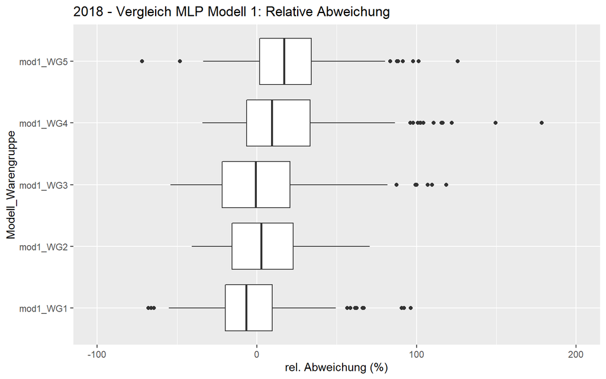

```r
# füge die relativen Abweichungen für WG1 an und benenne die Spalte um
prog_MLP_vgl_relAbw <- df_MLP_test_mod1_WG1 %>% dplyr::select(Datum, Abweichung_rel)
colnames(prog_MLP_vgl_relAbw)[2]="mod1_WG1"

# füge die relativen Abweichungen für WG2 an und benenne die Spalte um
prog_MLP_vgl_relAbw <- left_join(prog_MLP_vgl_relAbw, df_MLP_test_mod1_WG2 %>% dplyr::select(Datum, Abweichung_rel),by="Datum")
colnames(prog_MLP_vgl_relAbw)[3]="mod1_WG2"

# füge die relativen Abweichungen für WG3 an und benenne die Spalte um
prog_MLP_vgl_relAbw <- left_join(prog_MLP_vgl_relAbw, df_MLP_test_mod1_WG3 %>% dplyr::select(Datum, Abweichung_rel),by="Datum")
colnames(prog_MLP_vgl_relAbw)[4]="mod1_WG3"

# füge die relativen Abweichungen für WG4 an und benenne die Spalte um
prog_MLP_vgl_relAbw <- left_join(prog_MLP_vgl_relAbw, df_MLP_test_mod1_WG4 %>% dplyr::select(Datum, Abweichung_rel),by="Datum")
colnames(prog_MLP_vgl_relAbw)[5]="mod1_WG4"

# füge die relativen Abweichungen für WG5 an und benenne die Spalte um
prog_MLP_vgl_relAbw <- left_join(prog_MLP_vgl_relAbw, df_MLP_test_mod1_WG5 %>% dplyr::select(Datum, Abweichung_rel),by="Datum")
colnames(prog_MLP_vgl_relAbw)[6]="mod1_WG5"

# pivotieren
prog_MLP_vgl_relAbw <- prog_MLP_vgl_relAbw %>%
  pivot_longer(cols=-c("Datum"), names_to="Modell", values_to="Abweichung_rel")

# Boxplot
prog_MLP_vgl_relAbw %>%
  ggplot(mapping=aes(x=Modell, y=Abweichung_rel*100)) +
  geom_boxplot() + coord_flip() +
  ggtitle("2018 - Vergleich MLP Modell 1: Relative Abweichung") +
  xlab("Modell_Warengruppe") +
  ylab("rel. Abweichung (%)") +
  ylim(-100, 200)
```

### Modell 2 (MLP_mod2)

Im zweiten Schritt erweitern wir unser Modell und verwenden noch KielerWoche, Temperatur, Silvester_ext und Monat als Inputvariablen. Monat_c wurde dafür dummyfiziert. Und die Temperatur ist in 4 Bereiche und damit 4 Binärvariablen umgewandelt worden, damit wir einheitlich nur Binär-Inputs verwenden.

Wir haben je ein Modell pro Warengruppe trainiert. Python liefert uns folgende finalen Parameter als train error:

[output not shown]

Wenn wir in Python die trainierten Modelle auf die Testdaten anwenden, erhalten wir Umsatzschätzer je Warengruppe, die wir als csv hier einladen.

```r
df_MLP_test_mod2_WG1_pred <- read_csv("data/df_MLP_test_mod2_WG1_pred.csv", col_names = FALSE)
df_MLP_test_mod2_WG2_pred <- read_csv("data/df_MLP_test_mod2_WG2_pred.csv", col_names = FALSE)
df_MLP_test_mod2_WG3_pred <- read_csv("data/df_MLP_test_mod2_WG3_pred.csv", col_names = FALSE)
df_MLP_test_mod2_WG4_pred <- read_csv("data/df_MLP_test_mod2_WG4_pred.csv", col_names = FALSE)
df_MLP_test_mod2_WG5_pred <- read_csv("data/df_MLP_test_mod2_WG5_pred.csv", col_names = FALSE)
colnames(df_MLP_test_mod2_WG1_pred) <- "Umsatz_mod2_WG1"
colnames(df_MLP_test_mod2_WG2_pred) <- "Umsatz_mod2_WG2"
colnames(df_MLP_test_mod2_WG3_pred) <- "Umsatz_mod2_WG3"
colnames(df_MLP_test_mod2_WG4_pred) <- "Umsatz_mod2_WG4"
colnames(df_MLP_test_mod2_WG5_pred) <- "Umsatz_mod2_WG5"
```

Füge die Ergebnisse an die Test-Daten (für jede Warengruppe) und erstelle dann eine gemeinsame Übersichtstabelle für die Gütekennzahlen `prog_MLP_vgl_kennz_mod2`:

```r
# mod2_WG1
df_MLP_test_mod2_WG1 <- cbind(df_MLP_test_WG1, df_MLP_test_mod2_WG1_pred)

# ergänze Prognose_zuhoch (TRUE / FALSE), Abweichung (Schätzer - Umsatz), absolute Abweichung (Abweichung_abs), relative Abweichung (Abweichung_rel), quadratische Abweichung (Abweichung_quad)
df_MLP_test_mod2_WG1 <- df_MLP_test_mod2_WG1 %>%
  mutate(Prognose_zuhoch = (Umsatz_mod2_WG1 >= Umsatz)) %>%
  mutate(Abweichung = Umsatz_mod2_WG1 - Umsatz) %>%
  mutate(Abweichung_abs = abs(Umsatz_mod2_WG1 - Umsatz)) %>%
  mutate(Abweichung_rel = (Umsatz_mod2_WG1 - Umsatz) / Umsatz) %>%
  mutate(Abweichung_quad = Abweichung^2)

# Ergänze die benötigten Hilfsgrößen
df_MLP_test_mod2_WG1 <-  df_MLP_test_mod2_WG1 %>%
  mutate(Abweichung_rel_abs = abs(Abweichung_rel), Abweichung_rel_abs_mult_umsatz = Abweichung_rel_abs * Umsatz)

# Prognosegüte: mittlere Abweichung, mittlere absolute / relative Abweichung, mittlere quadratische Abweichung
temp <- df_MLP_test_mod2_WG1 %>%
  group_by() %>%
  summarise(Anzahl=n(), Umsatz_ges = round(sum(Umsatz)), Umsatz_mittel = round(sum(Umsatz)/n()), MAE = round(mean(Abweichung_abs)), MPE = round(mean(Abweichung_rel)*100), MAPE = round(mean(Abweichung_rel_abs)*100), WAPE = round(sum(Abweichung_rel_abs_mult_umsatz)/sum(Umsatz)*100), MSE = round(mean(Abweichung_quad)), RMSE = round(sqrt(mean(Abweichung_quad))))

# füge das Modell hinzu
temp <- temp %>% mutate(Modell = "mod2_WG1")

# füge die Kennzahlen nun an die Vergleichstabelle
prog_MLP_vgl_kennz_mod2 <- temp


# mod2_WG2
df_MLP_test_mod2_WG2 <- cbind(df_MLP_test_WG2, df_MLP_test_mod2_WG2_pred)

# ergänze Prognose_zuhoch (TRUE / FALSE), Abweichung (Schätzer - Umsatz), absolute Abweichung (Abweichung_abs), relative Abweichung (Abweichung_rel), quadratische Abweichung (Abweichung_quad)
df_MLP_test_mod2_WG2 <- df_MLP_test_mod2_WG2 %>%
  mutate(Prognose_zuhoch = (Umsatz_mod2_WG2 >= Umsatz)) %>%
  mutate(Abweichung = Umsatz_mod2_WG2 - Umsatz) %>%
  mutate(Abweichung_abs = abs(Umsatz_mod2_WG2 - Umsatz)) %>%
  mutate(Abweichung_rel = (Umsatz_mod2_WG2 - Umsatz) / Umsatz) %>%
  mutate(Abweichung_quad = Abweichung^2)

# Ergänze die benötigten Hilfsgrößen
df_MLP_test_mod2_WG2 <-  df_MLP_test_mod2_WG2 %>%
  mutate(Abweichung_rel_abs = abs(Abweichung_rel), Abweichung_rel_abs_mult_umsatz = Abweichung_rel_abs * Umsatz)

# Prognosegüte: mittlere Abweichung, mittlere absolute / relative Abweichung, mittlere quadratische Abweichung
temp <- df_MLP_test_mod2_WG2 %>%
  group_by() %>%
  summarise(Anzahl=n(), Umsatz_ges = round(sum(Umsatz)), Umsatz_mittel = round(sum(Umsatz)/n()), MAE = round(mean(Abweichung_abs)), MPE = round(mean(Abweichung_rel)*100), MAPE = round(mean(Abweichung_rel_abs)*100), WAPE = round(sum(Abweichung_rel_abs_mult_umsatz)/sum(Umsatz)*100), MSE = round(mean(Abweichung_quad)), RMSE = round(sqrt(mean(Abweichung_quad))))

# füge das Modell hinzu
temp <- temp %>% mutate(Modell = "mod2_WG2")

# füge die Kennzahlen nun an die Vergleichstabelle
prog_MLP_vgl_kennz_mod2 <- rbind(prog_MLP_vgl_kennz_mod2, temp)


# mod2_WG3
df_MLP_test_mod2_WG3 <- cbind(df_MLP_test_WG3, df_MLP_test_mod2_WG3_pred)

# ergänze Prognose_zuhoch (TRUE / FALSE), Abweichung (Schätzer - Umsatz), absolute Abweichung (Abweichung_abs), relative Abweichung (Abweichung_rel), quadratische Abweichung (Abweichung_quad)
df_MLP_test_mod2_WG3 <- df_MLP_test_mod2_WG3 %>%
  mutate(Prognose_zuhoch = (Umsatz_mod2_WG3 >= Umsatz)) %>%
  mutate(Abweichung = Umsatz_mod2_WG3 - Umsatz) %>%
  mutate(Abweichung_abs = abs(Umsatz_mod2_WG3 - Umsatz)) %>%
  mutate(Abweichung_rel = (Umsatz_mod2_WG3 - Umsatz) / Umsatz) %>%
  mutate(Abweichung_quad = Abweichung^2)

# Ergänze die benötigten Hilfsgrößen
df_MLP_test_mod2_WG3 <-  df_MLP_test_mod2_WG3 %>%
  mutate(Abweichung_rel_abs = abs(Abweichung_rel), Abweichung_rel_abs_mult_umsatz = Abweichung_rel_abs * Umsatz)

# Prognosegüte: mittlere Abweichung, mittlere absolute / relative Abweichung, mittlere quadratische Abweichung
temp <- df_MLP_test_mod2_WG3 %>%
  group_by() %>%
  summarise(Anzahl=n(), Umsatz_ges = round(sum(Umsatz)), Umsatz_mittel = round(sum(Umsatz)/n()), MAE = round(mean(Abweichung_abs)), MPE = round(mean(Abweichung_rel)*100), MAPE = round(mean(Abweichung_rel_abs)*100), WAPE = round(sum(Abweichung_rel_abs_mult_umsatz)/sum(Umsatz)*100), MSE = round(mean(Abweichung_quad)), RMSE = round(sqrt(mean(Abweichung_quad))))

# füge das Modell hinzu
temp <- temp %>% mutate(Modell = "mod2_WG3")

# füge die Kennzahlen nun an die Vergleichstabelle
prog_MLP_vgl_kennz_mod2 <- rbind(prog_MLP_vgl_kennz_mod2, temp)


# mod2_WG4
df_MLP_test_mod2_WG4 <- cbind(df_MLP_test_WG4, df_MLP_test_mod2_WG4_pred)

# ergänze Prognose_zuhoch (TRUE / FALSE), Abweichung (Schätzer - Umsatz), absolute Abweichung (Abweichung_abs), relative Abweichung (Abweichung_rel), quadratische Abweichung (Abweichung_quad)
df_MLP_test_mod2_WG4 <- df_MLP_test_mod2_WG4 %>%
  mutate(Prognose_zuhoch = (Umsatz_mod2_WG4 >= Umsatz)) %>%
  mutate(Abweichung = Umsatz_mod2_WG4 - Umsatz) %>%
  mutate(Abweichung_abs = abs(Umsatz_mod2_WG4 - Umsatz)) %>%
  mutate(Abweichung_rel = (Umsatz_mod2_WG4 - Umsatz) / Umsatz) %>%
  mutate(Abweichung_quad = Abweichung^2)

# Ergänze die benötigten Hilfsgrößen
df_MLP_test_mod2_WG4 <-  df_MLP_test_mod2_WG4 %>%
  mutate(Abweichung_rel_abs = abs(Abweichung_rel), Abweichung_rel_abs_mult_umsatz = Abweichung_rel_abs * Umsatz)

# Prognosegüte: mittlere Abweichung, mittlere absolute / relative Abweichung, mittlere quadratische Abweichung
temp <- df_MLP_test_mod2_WG4 %>%
  group_by() %>%
  summarise(Anzahl=n(), Umsatz_ges = round(sum(Umsatz)), Umsatz_mittel = round(sum(Umsatz)/n()), MAE = round(mean(Abweichung_abs)), MPE = round(mean(Abweichung_rel)*100), MAPE = round(mean(Abweichung_rel_abs)*100), WAPE = round(sum(Abweichung_rel_abs_mult_umsatz)/sum(Umsatz)*100), MSE = round(mean(Abweichung_quad)), RMSE = round(sqrt(mean(Abweichung_quad))))

# füge das Modell hinzu
temp <- temp %>% mutate(Modell = "mod2_WG4")

# füge die Kennzahlen nun an die Vergleichstabelle
prog_MLP_vgl_kennz_mod2 <- rbind(prog_MLP_vgl_kennz_mod2, temp)


# mod2_WG5
df_MLP_test_mod2_WG5 <- cbind(df_MLP_test_WG5, df_MLP_test_mod2_WG5_pred)

# ergänze Prognose_zuhoch (TRUE / FALSE), Abweichung (Schätzer - Umsatz), absolute Abweichung (Abweichung_abs), relative Abweichung (Abweichung_rel), quadratische Abweichung (Abweichung_quad)
df_MLP_test_mod2_WG5 <- df_MLP_test_mod2_WG5 %>%
  mutate(Prognose_zuhoch = (Umsatz_mod2_WG5 >= Umsatz)) %>%
  mutate(Abweichung = Umsatz_mod2_WG5 - Umsatz) %>%
  mutate(Abweichung_abs = abs(Umsatz_mod2_WG5 - Umsatz)) %>%
  mutate(Abweichung_rel = (Umsatz_mod2_WG5 - Umsatz) / Umsatz) %>%
  mutate(Abweichung_quad = Abweichung^2)

# Ergänze die benötigten Hilfsgrößen
df_MLP_test_mod2_WG5 <-  df_MLP_test_mod2_WG5 %>%
  mutate(Abweichung_rel_abs = abs(Abweichung_rel), Abweichung_rel_abs_mult_umsatz = Abweichung_rel_abs * Umsatz)

# Prognosegüte: mittlere Abweichung, mittlere absolute / relative Abweichung, mittlere quadratische Abweichung
temp <- df_MLP_test_mod2_WG5 %>%
  group_by() %>%
  summarise(Anzahl=n(), Umsatz_ges = round(sum(Umsatz)), Umsatz_mittel = round(sum(Umsatz)/n()), MAE = round(mean(Abweichung_abs)), MPE = round(mean(Abweichung_rel)*100), MAPE = round(mean(Abweichung_rel_abs)*100), WAPE = round(sum(Abweichung_rel_abs_mult_umsatz)/sum(Umsatz)*100), MSE = round(mean(Abweichung_quad)), RMSE = round(sqrt(mean(Abweichung_quad))))

# füge das Modell hinzu
temp <- temp %>% mutate(Modell = "mod2_WG5")

# füge die Kennzahlen nun an die Vergleichstabelle
prog_MLP_vgl_kennz_mod2 <- rbind(prog_MLP_vgl_kennz_mod2, temp)

prog_MLP_vgl_kennz_mod2
```

```
## # A tibble: 5 x 10
##   Anzahl Umsatz_ges Umsatz_mittel   MAE   MPE  MAPE  WAPE   MSE  RMSE
##    <int>      <dbl>         <dbl> <dbl> <dbl> <dbl> <dbl> <dbl> <dbl>
## 1    346      45738           132    27    -4    21    20  1453    38
## 2    346     130413           377    46     7    13    12  3519    59
## 3    346      59316           171    34    -9    19    20  2051    45
## 4    345      28354            82    18     5    22    22   572    24
## 5    346      93912           271    43    -1    16    16  3367    58
## # ... with 1 more variable: Modell <chr>
```

Das erweiterte Modell (mod2) liefert im Gegensatz zum einfachen Modell (mod1) einheitlichere Ergebnisse für die verschiedenen Warengruppen: Zunächst fällt auf, dass die mittlere relative Abweichung (MPE) nun für die beiden Warengruppen 4 und 5 nahe Null liegt und sich unser Schätzer für die Warengruppen 2 und 3 von Null entfernt haben.

Der gewichtete mittlere Absolutwert der relativen Abweichung (WAPE) zeigt wieder für die Warengruppe 2 den niedrigsten Fehler und liegt jetzt auf einem vergleichbaren Niveau zum besten naiven Schätzmodell (glDS_4T_erw), für Warengruppe 2 hatten wir dort einen WAPE = 11 gesehen.

Als nächstes wollen wir uns die Verteilung der relativen Abweichungen der Umsatzschätzung vom tatsächlichen Umsatz angucken und erstellen dafür eine weitere Vergleichstabelle `prog_MLP_vgl_relAbw_mod2`. Diese müssen wir dann noch pivotieren (pivot_longer) als Vorbereitung auf den Boxplot:

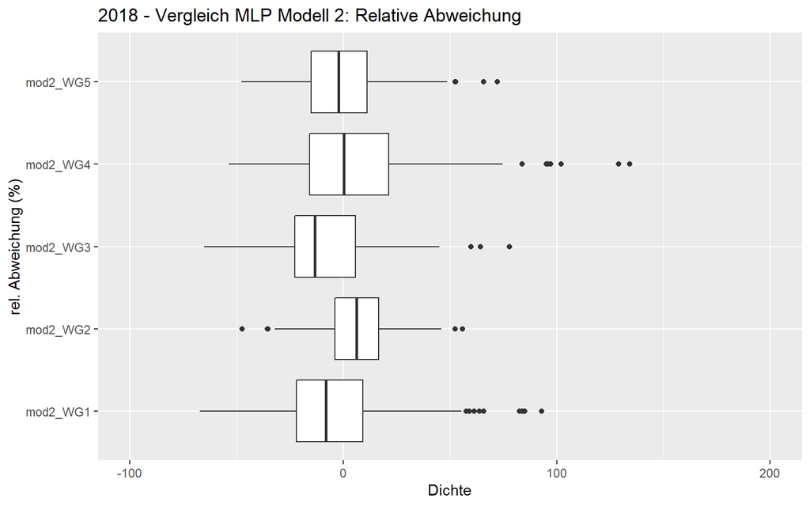

```r
# füge die relativen Abweichungen für WG1 an und benenne die Spalte um
prog_MLP_vgl_relAbw_mod2 <- df_MLP_test_mod2_WG1 %>% dplyr::select(Datum, Abweichung_rel)
colnames(prog_MLP_vgl_relAbw_mod2)[2]="mod2_WG1"

# füge die relativen Abweichungen für WG2 an und benenne die Spalte um
prog_MLP_vgl_relAbw_mod2 <- left_join(prog_MLP_vgl_relAbw_mod2, df_MLP_test_mod2_WG2 %>% dplyr::select(Datum, Abweichung_rel),by="Datum")
colnames(prog_MLP_vgl_relAbw_mod2)[3]="mod2_WG2"

# füge die relativen Abweichungen für WG3 an und benenne die Spalte um
prog_MLP_vgl_relAbw_mod2 <- left_join(prog_MLP_vgl_relAbw_mod2, df_MLP_test_mod2_WG3 %>% dplyr::select(Datum, Abweichung_rel),by="Datum")
colnames(prog_MLP_vgl_relAbw_mod2)[4]="mod2_WG3"

# füge die relativen Abweichungen für WG4 an und benenne die Spalte um
prog_MLP_vgl_relAbw_mod2 <- left_join(prog_MLP_vgl_relAbw_mod2, df_MLP_test_mod2_WG4 %>% dplyr::select(Datum, Abweichung_rel),by="Datum")
colnames(prog_MLP_vgl_relAbw_mod2)[5]="mod2_WG4"

# füge die relativen Abweichungen für WG5 an und benenne die Spalte um
prog_MLP_vgl_relAbw_mod2 <- left_join(prog_MLP_vgl_relAbw_mod2, df_MLP_test_mod2_WG5 %>% dplyr::select(Datum, Abweichung_rel),by="Datum")
colnames(prog_MLP_vgl_relAbw_mod2)[6]="mod2_WG5"

# pivotieren
prog_MLP_vgl_relAbw_mod2 <- prog_MLP_vgl_relAbw_mod2 %>%
  pivot_longer(cols=-c("Datum"), names_to="Modell", values_to="Abweichung_rel")

# Boxplot
prog_MLP_vgl_relAbw_mod2 %>%
  ggplot(mapping=aes(x=Modell, y=Abweichung_rel*100)) +
  geom_boxplot() + coord_flip() +
  ggtitle("2018 - Vergleich MLP Modell 2: Relative Abweichung") +
  xlab("rel. Abweichung (%)") +
  ylab("Dichte") +
  ylim(-100, 200)
```

Die Umsatzschätzung gelingt offenbar für die Warengruppe 2 (= Brötchen) ab besten.

## 8.5 Vergleich der MLP Modelle

### Fazit DL Modelle

Wir haben in diesem Abschnitt zwei Multilayer Perceptron Modelle eingesetzt und genauer untersucht. Die Ergebnisse sind brauchbar aber nicht umwerfend. In beiden Modellen haben wir stochastic gradiend descent einen iterativen Lernalgorithmus verwendet, der keine Garantie gibt, das globale Optimum für die Gewichte und Schwellwerte zu finden. Das kann ein Grund für die mangelnde Ergebnis-Qualität sein.

Die Parameter - wie bspw. die Lernrate, die Anzahl der hidden layers und der Anzahl der Neuronen im hidden layer - haben wir empirisch festgelegt. Hierfür gibt es keine “optimalen Werte”.

Insgesamt stellen wir fest, dass die so gebauten MLP Modelle dem Problem nicht gerecht werden. Vermutlich würde man mit rekursiven Netzen und/oder dem Einsatz von long-short-term-memory (LSTM) Einheiten deutlich bessere Ergebnisse erzielen. Das sprengt jedoch den Umfang dieser Projektarbeit und wird daher nicht weiter betrachtet.

Wir hatten gesehen, dass das komplexe Modell (mod2) für die Warengruppe 2 in Bezug auf den WAPE gute Ergebnisse liefert. Ein Ansatz ist, das Modell gezielt für diese Warengruppe noch zu erweitern. Hier haben wir versucht, einen zweiten hidden layer mit 20 Einheiten in das Modell zu integrieren. Allerdings verschlechterten sich dadurch die Prognose-Ergebnisse, so dass wir den Ansatz nicht weiter verfolgt haben. Alternativ haben wir ein Kompromiss-Modell (mod3) getestet, das nur die Variablen SommerferienSH, Feiertag, Silvester_ext, Samstag, Sonntag, Juli und August enthält. Und dieses Modell haben wir versucht, für Warengruppe 2 zu optimieren durch Variation der Units im hidden layer, Anwendung anderer Lernalgorithmen (Adam) oder Hinzunahme eines weiteren hidden layers - ohne Erfolg.

Auch könnte man das Modell gezielt auf die Feiertags-Effekte trainieren, um dafür bessere Ergebnisse zu erzielen. Diese Idee stellt eine Ausbaustufe dar, die wir hier nicht umgesetzt haben.

Insgesamt ging es hier eher darum, Erfahrungswerte in der praktischen Anwendung von DL-Verfahren zu sammeln und das ist in der Tat sehr gut gelungen.

## 8.6 Zugabe

Weil wir uns vom MLP bessere Ergebnisse erhofft hatten, haben wir noch einen drauf gesetzt und noch ein viertes MLP (mod4) getestet. Dafür haben wir den vollständigen SVM-Datensatz verwendet mit allen Inputvariablen und skalierten Wettervariablen sowie skaliertem Umsatz.

Getestet haben wir wieder sequentielle MLP-Modelle, diesmal aber gezielt mit mehreren hidden layers. Die besten Ergebnisse lieferte ein MOdell mit zwei hidden layers, bestehend aus 100 bzw. 50 Einheiten, jeweils mit ‘relu’ Aktivierungsfunktionen. Als Lernalgorithmus haben wir dabei ‘Adam’ angewendet mit einer Lernrate von 0.001, gleichzeitig haben wir online learning (batch_size = 1) angewendet und das Modell über 20 Epochen trainiert.

Diese Parametereinstellungen lieferten die besten Ergebnisse (df_MLP_test_mod4_WG2_pred.csv). Verlängert man die Trainingsphase um weitere 20 Epochen (df_MLP_test_mod4_WG2_pred2.csv), verschlechtert sich die Prognosegüte bei Anwendung des Modells auf die Testdaten. Ein dritter hidden layer mit 25 Einheiten (df_MLP_test_mod4_WG2_pred3.csv) bringt keinen Mehrwert. Und auch wenn man die Anzahl der Einheiten im ersten hidden layer verdoppelt (df_MLP_test_mod4_WG2_pred4.csv), erzielt man keine genaueren Schätzwerte.

Hier die Testergebnisse - exemplarisch für Warengruppe 2:

```r
df_MLP_test_mod4_WG2_pred <- read_csv("data/df_MLP_test_mod4_WG2_pred.csv", col_names = FALSE)

colnames(df_MLP_test_mod4_WG2_pred) <- "Umsatz_mod4_WG2"
```

Füge die Ergebnisse an die Test-Daten und bilde die Gütekennzahlen. Vorher müssen wir den Umsatz wieder zurück skalieren:

```r
# mod1_WG1
df_MLP_test_mod4_WG2 <- cbind(df_SVM_test_WG2, df_MLP_test_mod4_WG2_pred)

# ergänze Prognose_zuhoch (TRUE / FALSE), Abweichung (Schätzer - Umsatz), absolute Abweichung (Abweichung_abs), relative Abweichung (Abweichung_rel), quadratische Abweichung (Abweichung_quad)
df_MLP_test_mod4_WG2 <- df_MLP_test_mod4_WG2 %>%
  mutate(Umsatz = Umsatz * 2000) %>%
  mutate(Umsatz_mod4_WG2 = Umsatz_mod4_WG2 * 2000) %>%
  mutate(Prognose_zuhoch = (Umsatz_mod4_WG2 >= Umsatz)) %>%
  mutate(Abweichung = Umsatz_mod4_WG2 - Umsatz) %>%
  mutate(Abweichung_abs = abs(Umsatz_mod4_WG2 - Umsatz)) %>%
  mutate(Abweichung_rel = (Umsatz_mod4_WG2 - Umsatz) / Umsatz) %>%
  mutate(Abweichung_quad = Abweichung^2)

# Ergänze die benötigten Hilfsgrößen
df_MLP_test_mod4_WG2 <-  df_MLP_test_mod4_WG2 %>%
  mutate(Abweichung_rel_abs = abs(Abweichung_rel), Abweichung_rel_abs_mult_umsatz = Abweichung_rel_abs * Umsatz)

# Prognosegüte: mittlere Abweichung, mittlere absolute / relative Abweichung, mittlere quadratische Abweichung
df_MLP_test_mod4_WG2 %>%
  group_by() %>%
  summarise(Anzahl=n(), Umsatz_ges = round(sum(Umsatz)), Umsatz_mittel = round(sum(Umsatz)/n()), MAE = round(mean(Abweichung_abs)), MPE = round(mean(Abweichung_rel)*100), MAPE = round(mean(Abweichung_rel_abs)*100), WAPE = round(sum(Abweichung_rel_abs_mult_umsatz)/sum(Umsatz)*100), MSE = round(mean(Abweichung_quad)), RMSE = round(sqrt(mean(Abweichung_quad))))
```

```
## # A tibble: 1 x 9
##   Anzahl Umsatz_ges Umsatz_mittel   MAE   MPE  MAPE  WAPE   MSE  RMSE
##    <int>      <dbl>         <dbl> <dbl> <dbl> <dbl> <dbl> <dbl> <dbl>
## 1    346     130413           377    39     2    11    10  2594    51
```

Der WAPE liegt bei 10 und damit knapp unterhalb des besten naiven Modells. Das hat uns ermutigt, Modell 4 auf eine andere Warengruppe anzuwenden.

Hier die Ergebnisse für Warengruppe 4:

```r
df_MLP_test_mod4_WG4_pred <- read_csv("data/df_MLP_test_mod4_WG4_pred.csv", col_names = FALSE)

colnames(df_MLP_test_mod4_WG4_pred) <- "Umsatz_mod4_WG4"
```

Füge die Ergebnisse an die Test-Daten und bilde die Gütekennzahlen. VORHER den Umsatz wieder zurück skalieren:

```r
# mod1_WG1
df_MLP_test_mod4_WG4 <- cbind(df_SVM_test_WG4, df_MLP_test_mod4_WG4_pred)

# ergänze Prognose_zuhoch (TRUE / FALSE), Abweichung (Schätzer - Umsatz), absolute Abweichung (Abweichung_abs), relative Abweichung (Abweichung_rel), quadratische Abweichung (Abweichung_quad)
df_MLP_test_mod4_WG4 <- df_MLP_test_mod4_WG4 %>%
  mutate(Umsatz = Umsatz * 2000) %>%
  mutate(Umsatz_mod4_WG4 = Umsatz_mod4_WG4 * 2000) %>%
  mutate(Prognose_zuhoch = (Umsatz_mod4_WG4 >= Umsatz)) %>%
  mutate(Abweichung = Umsatz_mod4_WG4 - Umsatz) %>%
  mutate(Abweichung_abs = abs(Umsatz_mod4_WG4 - Umsatz)) %>%
  mutate(Abweichung_rel = (Umsatz_mod4_WG4 - Umsatz) / Umsatz) %>%
  mutate(Abweichung_quad = Abweichung^2)

# Ergänze die benötigten Hilfsgrößen
df_MLP_test_mod4_WG4 <-  df_MLP_test_mod4_WG4 %>%
  mutate(Abweichung_rel_abs = abs(Abweichung_rel), Abweichung_rel_abs_mult_umsatz = Abweichung_rel_abs * Umsatz)

# Prognosegüte: mittlere Abweichung, mittlere absolute / relative Abweichung, mittlere quadratische Abweichung
df_MLP_test_mod4_WG4 %>%
  group_by() %>%
  summarise(Anzahl=n(), Umsatz_ges = round(sum(Umsatz)), Umsatz_mittel = round(sum(Umsatz)/n()), MAE = round(mean(Abweichung_abs)), MPE = round(mean(Abweichung_rel)*100), MAPE = round(mean(Abweichung_rel_abs)*100), WAPE = round(sum(Abweichung_rel_abs_mult_umsatz)/sum(Umsatz)*100), MSE = round(mean(Abweichung_quad)), RMSE = round(sqrt(mean(Abweichung_quad))))
```

```
## # A tibble: 1 x 9
##   Anzahl Umsatz_ges Umsatz_mittel   MAE   MPE  MAPE  WAPE   MSE  RMSE
##    <int>      <dbl>         <dbl> <dbl> <dbl> <dbl> <dbl> <dbl> <dbl>
## 1    345      28354            82    19    13    25    23   741    27
```

Unsere Hoffnung hat sich jedoch nicht erfüllt: Der WAPE ist schlechter als für das einfachere Modell 2 (mod2) für die Warengruppe 4.

# 9. Modellvergleich über alle verwendeten Verfahren

```r
Modellvergleich_total <- rbind(prog_MLP_vgl_kennz_mod2, lm_vgl_kennz)

Modellvergleich_total
```

```
## # A tibble: 13 x 10
##    Anzahl Umsatz_ges Umsatz_mittel   MAE   MPE  MAPE  WAPE   MSE  RMSE
##     <int>      <dbl>         <dbl> <dbl> <dbl> <dbl> <dbl> <dbl> <dbl>
##  1    346      45738           132    27    -4    21    20  1453    38
##  2    346     130413           377    46     7    13    12  3519    59
##  3    346      59316           171    34    -9    19    20  2051    45
##  4    345      28354            82    18     5    22    22   572    24
##  5    346      93912           271    43    -1    16    16  3367    58
##  6    346      45738           132    23    -4    18    18   965    31
##  7    346      45738           132    23    -4    18    18   949    31
##  8    346     130413           377    45     9    13    12  3161    56
##  9    346     130413           377    45     9    13    12  3189    56
## 10    346     130413           377    45     9    13    12  3197    57
## 11    346      93912           271    38     4    15    14  2538    50
## 12    346      93912           271    39     4    15    14  2570    51
## 13    346      93912           271    38     4    14    14  2541    50
## # ... with 1 more variable: Modell <chr>
```

Christina M. Mädge, Marco Landt-Hayen

6.4.2020